# mtDNA Mutational Analysis - comparator tissues (primarily the ‘non-blood’ dataset)

Mike Spencer Chapman

2026-09-16

This markdown goes through all the analysis on the comparator cross-tissue dataset from the manuscript “Mitochondrial mutation, drift and selection during human development and ageing”.

## Set file paths.

Manually set these file paths before running the script - this needs a local copy of the hg19 genome file

```r
#genomeFile is set in config.R
source(here::here("config.R")) #sets root_dir, genomeFile, project paths and my_markdown_theme
set_markdown_figure_defaults() #larger default figure size for on-screen reading
```

Set the secondary file paths used throughout the script. This data is all included in the github repository.

```r
#Source the necessary functions - included in the repo
source(paste0(root_dir,"/data/mito_mutations_blood_functions.R"))

#Set the key file paths using the root dir
tree_file_paths = list.files(paste0(root_dir,"/data/tree_files"),pattern=".tree",full.names = T)
ref_file=paste0(root_dir,"/data/Samples_metadata_ref.csv")
nonblood_ref_file=paste0(root_dir,"/data/metadata/non_blood_metadata.xlsx")
colony_info_file=paste0(root_dir,"/data/metadata/colonyinfo_AX001_KX001_KX002_KX003_TX001_TX002_CB001.txt")
plots_dir=notebook_plots_dir("mtDNA_mutations_comparator_tissues")

# read in the trinucleotide context data
mtdna_trinuc_freq_path=paste0(root_dir,"/data/mtDNA_trinuc_freqs_coding_dloop_heavy_light.Rds")
mtdna_trinuc_freq <- readRDS(mtdna_trinuc_freq_path)

# set regions for coding and dloop regions - important for the mutation profiles
coding_region <- 577:16023
d_loop_region <- c(1:576,16024:16569)

#Set the basic plotting theme for ggplot2
#my_markdown_theme is defined in config.R


#Read in the mitochondrial copy number data
mito_cn=read.csv(paste0(root_dir,"/data/whole_genome_coverage_pileup_and_bedtools_annotated.csv"),header=T)%>%
  dplyr::rename("pileup_median_mtDNA_coverage"=pilup_median_mtDNA_coverage) #This column has a typo

#Import individual level metadata for the adult and foetal blood samples
ref_df<-readxl::read_excel(nonblood_ref_file) #Import metadata relating to all individuals studied
colony_info<-read.delim(colony_info_file) #Import colony-level data for the lymphoid dataset as there are multiple different cell types
```

Set some other variables and colour schemes used in the script. e.g. defining which initials are used as keys for which dataset.

(out of interest, these are generally the initials of the principal scientist who generated that data, e.g. KY = “Kenichi Yoshida”)

```r
#Define the dataframe for converting IDs between my IDs, and Andrew's for the different datasets
translate=data.frame(dataset=c("KY","HL","SO","PR","LM","NW","lymph","EM"),
                     al_ref=c("lung_organoid","colon","colon_ibd","muty_mutant","endometrium","blood_MPN","immune","blood_emily"))

muty_samples=c("PD44887","PD44888","PD44889","PD44890","PD44891")

#Define a set of 'black-listed' mutations - these are sets of artefacts that recurrently slip through the filters
#This is often due to haplotype-specific artefacts that map as SNVs
exclude_muts=c("MT_302_A_C","MT_311_C_T","MT_456_C_T","MT_567_A_C","MT_574_A_C","MT_8270_C_T","MT_16170_A_C","MT_16181_A_C","MT_16182_A_C","MT_16183_A_C","MT_16189_T_C")

#Set up objects for colour schemes and renaming tissues for plots
mut_type_cols<-c("#00468B","#925E9F","#925E9F","#810F7C","black","#E10C04","black")
names(mut_type_cols)<-c("Missense","Nonsense","Truncating","Stop_loss","Non-Coding","Synonymous","Overall")

name_conversion_vec=c("Normal blood","Lymphoid","MPN","Colon","IBD-affected\nColon","MUTYH-mutant\nColon","Endometrium","Bronchial\nepithelium")
names(name_conversion_vec)=c("blood","lymph","NW","HL","SO","PR","LM","KY")
tissue_cols<-c("#96e97c","#fd81c8","#145a6a","#65e6f9","#781486","#5f70cc","#aea2eb","#1d6d1f")
names(tissue_cols)<-name_conversion_vec
```

## IMPORT ALL DATASETS

```r
all_cohorts_plus_CML<-c("KY","HL","SO","PR","LM","NW","CML","lymph","blood")
all_cohorts<-c("KY","HL","SO","PR","LM","NW","lymph","blood")

all_mito_datasets<-lapply(all_cohorts_plus_CML,function(dataset) {

  dataset_mito_data<-readRDS(paste0(root_dir,"/data/nonblood/mito_mutation_data_",dataset,".RDS"))
  CN_correlating_muts<-readRDS(paste0(root_dir,"/data/nonblood/CN_correlation_",dataset,".RDS"))

  rho_cut_off=0

  #Deal with the germline mutations (if not done already)
  dataset_mito_data<-Map(list=dataset_mito_data,exp_ID=names(dataset_mito_data),function(list,exp_ID) {
    if(is.null(list$germline_muts)) {
      list$germline_muts<-identify_germline(matrices=list$matrices,threshold=0.9)
      cat(list$germline_muts,sep="\n")
      list$matrices<-reverse_germline(matrices=list$matrices,threshold=0.9)
    }
    return(list)
  })

  #Sort out the names of the mutCN column
  dataset_mito_data<-lapply(dataset_mito_data,function(list) {
    colnames(list$matrices$implied_mutCN)<-stringr::str_split(colnames(list$matrices$implied_mutCN),pattern = '\\.\\.\\.',simplify=T)[,1]
    return(list)
  })

  #Add the CN correlating muts vector to each patient (slightly inefficient but programatically more straight-forward)
  dataset_mito_data<-lapply(dataset_mito_data,function(list) {
    list$CN_correlating_muts<-CN_correlating_muts
    return(list)
  })


  #cat("Adding the filtered VAF matrix.",sep="\n")

  #Annotate specific mutations with their most likely signature using the 'sig_ref' dataframe
  dataset_mito_data<-Map(list=dataset_mito_data,this_exp_ID=names(dataset_mito_data),function(list,this_exp_ID) {

    #cat(this_exp_ID,sep="\n")

    if(dataset=="lymph") {list$tree$tip.label<-unique(list$sample_shearwater_calls$sampleID)}

    mutCN_cutoff=25 #If the mitochondrial copy number is over 25, retain mutation even if is in the "CN correlating muts" list
    CN_correlating_mut_removal_mat=list$matrices$implied_mutCN>mutCN_cutoff|(matrix((!rownames(list$matrices$vaf)%in%CN_correlating_muts),ncol=1)%*%matrix(rep(1,ncol(list$matrices$vaf)),nrow=1))
    vaf.filt<-(list$matrices$vaf[,list$tree$tip.label]*list$matrices$SW[,list$tree$tip.label][,list$tree$tip.label]*CN_correlating_mut_removal_mat[,list$tree$tip.label])[!grepl("DEL|INS",rownames(list$matrices$vaf))&
                                                                                                                                                                            list$rho_vals>rho_cut_off&
                                                                                                                                                                            !rownames(list$matrices$vaf)%in%exclude_muts,]

    list$matrices$CN_correlating_mut_removal_mat<-CN_correlating_mut_removal_mat
    list$matrices$vaf.filt<-vaf.filt
    return(list)
  })

  if(dataset=="lymph") {
    dataset_mito_data<-Map(list=dataset_mito_data,exp_ID=names(dataset_mito_data),function(list,exp_ID) {
      if(!exp_ID=="TX001") {list$het_oocyte_muts<-c()}
      return(list)
    })
  }
  return(dataset_mito_data)
})
names(all_mito_datasets)<-all_cohorts_plus_CML
```

Convert this into tidy dataframe format. One dataframe per dataset.

```r
all_df_tidy<-Map(dataset=all_cohorts_plus_CML,dataset_mito_data=all_mito_datasets,function(dataset,dataset_mito_data) {
  cat(dataset,sep="\n")

  #Generate tidy data frame of samples, mutations and vafs
  mutCN_cutoff=25 #If the mitochondrial copy number is over 25, retain mutation even if is in the "CN correlating muts" list
  vaf_cut_off<-0.03
  rho_cut_off<-0
  CN_correlating_muts<-dataset_mito_data$CN_correlating_muts
  df_tidy<-dplyr::bind_rows(Map(list=dataset_mito_data,exp_ID=names(dataset_mito_data),function(list,exp_ID) {
    if(is.null(list)){stop(return(NULL))}
    CN_correlating_mut_removal_mat=list$matrices$CN_correlating_mut_removal_mat
    implied_mut_CN_tidy<-list$matrices$implied_mutCN%>%
      as.data.frame()%>%
      tibble::rownames_to_column(var="mut_ref")%>%
      tidyr::gather(key="Sample",value="implied_mut_CN",-mut_ref)
    df_tidy<-(list$matrices$vaf*list$matrices$SW*CN_correlating_mut_removal_mat)%>%
      as.data.frame()%>%
      tibble::rownames_to_column(var="mut_ref")%>%
      mutate(rho_val=list$rho_vals)%>%
      tidyr::gather(key="Sample",value="vaf",-mut_ref,-rho_val)

    comb_tidy<-left_join(df_tidy,implied_mut_CN_tidy,by=c("Sample","mut_ref"))%>%
      dplyr::filter(!grepl("DEL|INS",mut_ref) & !mut_ref%in%exclude_muts & !mut_ref%in%list$het_oocyte_muts)%>%
      dplyr::filter(vaf>=vaf_cut_off)%>%
      mutate(exp_ID=exp_ID)
    return(comb_tidy)
  }))

  #Filter the CN-correlating mutations - due to mis-mapping of nuclear reads.
  #There may be some genuine mutations at these sites, in which case the implied mutation copy number will be much higher than ~2 (here an arbitrary threshold of 8 is applied)
  df_tidy<-df_tidy%>%
    left_join(mito_cn,by="Sample")%>%
    mutate(implied_mut_CN=vaf*bedtools_mtDNA_genomes)%>%
    dplyr::filter(!(mut_ref%in%dataset_mito_data$CN_correlating_muts & implied_mut_CN<=mutCN_cutoff))

  return(df_tidy)
})
```

```
## KY
## HL
## SO
## PR
## LM
```

```
## NW
## CML
## lymph
## blood
```

## ASSESS MITOCHONDRIAL COVERAGE & UNIFORMITY

First just look at the mean mitochondrial coverage per sample as determined by bedtools. Plot this as tissue-specific histograms.

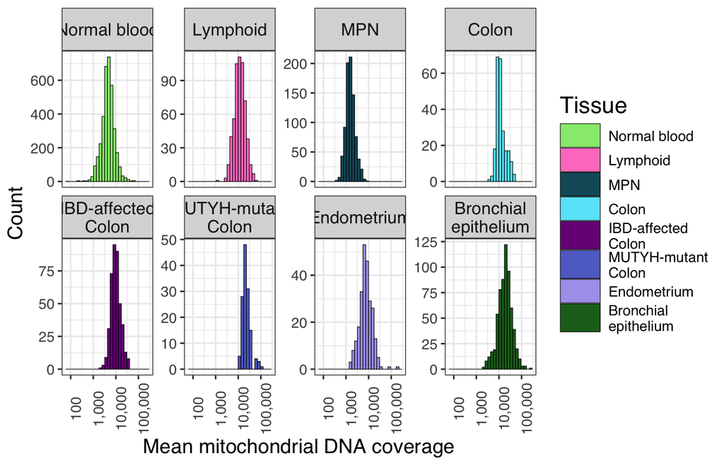

```r
name_conversion_vec=c("Normal blood","Lymphoid","MPN","Colon","IBD-affected\nColon","MUTYH-mutant\nColon","Endometrium","Bronchial\nepithelium")
names(name_conversion_vec)=c("blood","lymph","NW","HL","SO","PR","LM","KY")
tissue_cols<-c("#96e97c","#fd81c8","#145a6a","#65e6f9","#781486","#5f70cc","#aea2eb","#1d6d1f")
names(tissue_cols)<-name_conversion_vec

sample_summary_info<-Map(dataset=all_cohorts,list=all_mito_datasets[all_cohorts],function(dataset,list) {
  Map(ind=list,exp_ID=names(list),function(ind,exp_ID) {
    data.frame(dataset=dataset,exp_ID=exp_ID,SampleID=ind$tree$tip.label)
  })%>%dplyr::bind_rows()
})%>%dplyr::bind_rows()

#Mean coverage - histograms as facets
coverage.plot<-mito_cn%>%
  filter(Tissue%in%translate$al_ref)%>%
  right_join(sample_summary_info,by=c("Sample"="SampleID"))%>%
  mutate(Tissue=factor(name_conversion_vec[dataset],levels=name_conversion_vec))%>%
  filter(!is.na(bedtools_mtDNA_coverage))%>%
  ggplot(aes(x=bedtools_mtDNA_coverage,fill=Tissue))+
  geom_histogram(col="black",linewidth=0.2,bins=30)+
  scale_fill_manual(values=tissue_cols)+
  scale_x_log10(labels=scales::label_comma())+
  facet_wrap(~Tissue,scales = "free_y",nrow=2)+
  theme_bw()+
  my_markdown_theme+
  theme(axis.text.x = element_text(angle=90),strip.text.x = element_text(size = 12,margin = margin(1,0,1,0, "mm")))+
  labs(x="Mean mitochondrial DNA coverage",y="Count")
coverage.plot
```

```r
save_plot(filename=paste0(plots_dir,"coverage_by_tissue_plot.pdf"),coverage.plot,width=7,height=2.5)
```

Now use the median coverage across the mitochondrial, a more standard figure utilised in these studies.

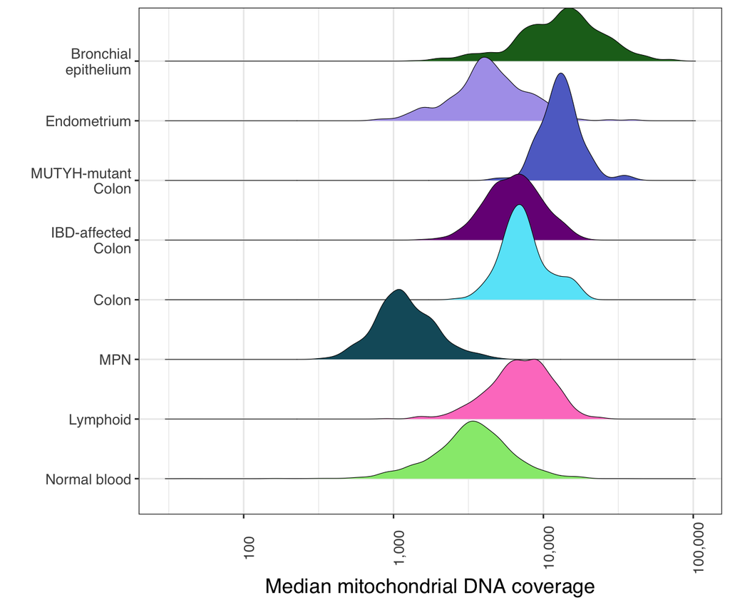

```r
#Median coverage - ridges plot
median.coverage.plot<-mito_cn%>%
  filter(Tissue%in%translate$al_ref)%>%
  right_join(sample_summary_info,by=c("Sample"="SampleID"))%>%
  mutate(Tissue=factor(name_conversion_vec[dataset],levels=name_conversion_vec))%>%
  filter(!is.na(pileup_median_mtDNA_coverage))%>%
  ggplot(aes(x=pileup_median_mtDNA_coverage,y=Tissue,fill=Tissue))+
  #geom_histogram(col="black",linewidth=0.2)+
  ggridges::geom_density_ridges(linewidth=0.2)+
  scale_fill_manual(values=tissue_cols,guide="none")+
  scale_x_log10(labels=scales::label_comma())+
  #facet_wrap(~Tissue,scales = "free_y",nrow=2)+
  theme_bw()+
  my_markdown_theme+
  theme(axis.text.x = element_text(angle=90),strip.text.x = element_text(size = 12,margin = margin(1,0,1,0, "mm")))+
  labs(x="Median mitochondrial DNA coverage",y="")
median.coverage.plot
```

```r
save_plot(filename=paste0(plots_dir,"median.coverage.plot.pdf"),median.coverage.plot,width=3.3,height=2.5)
```

Uniformity across the mtDNA genome is also a key marker of coverage quality. We use a very stringent marker of uniformity - the proportion of genome with >80% of the mean.

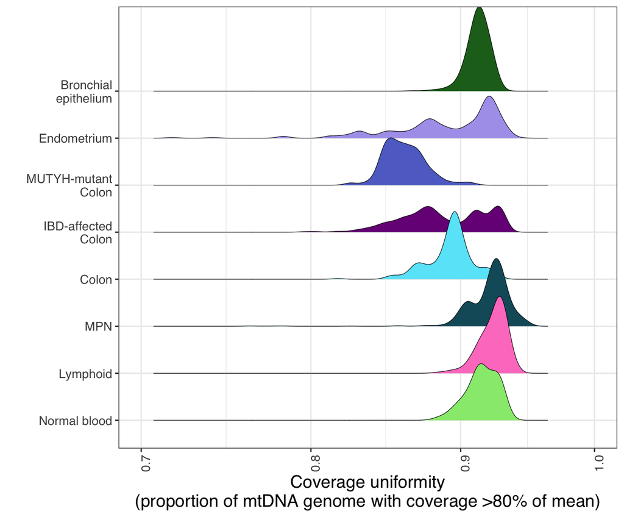

```r
uniformity_plot<-mito_cn%>%
  filter(Tissue%in%translate$al_ref)%>%
  right_join(sample_summary_info,by=c("Sample"="SampleID"))%>%
  mutate(Tissue=factor(name_conversion_vec[dataset],levels=name_conversion_vec))%>%
  filter(!is.na(perc_over0.8))%>%
  ggplot(aes(x=perc_over0.8,y=Tissue,fill=Tissue))+
  #geom_histogram(col="black",linewidth=0.2)+
  ggridges::geom_density_ridges(linewidth=0.2)+
  scale_fill_manual(values=tissue_cols,guide="none")+
  scale_x_log10(limits=c(0.7,1),breaks=seq(0.7,1,0.1))+
  #facet_wrap(~Tissue,scales = "free_y",nrow=2)+
  theme_bw()+
  my_markdown_theme+
  theme(axis.text.x = element_text(angle=90),strip.text.x = element_text(size = 12,margin = margin(1,0,1,0, "mm")))+
  labs(x="Coverage uniformity\n(proportion of mtDNA genome with coverage >80% of mean)",y="")
uniformity_plot
```

```r
save_plot(filename=paste0(plots_dir,"uniformity_plot.pdf"),uniformity_plot,width=3.3,height=2.5)
```

```r
#Print non-blood coverage summary statistics
#Per individual
mito_cn%>%
  filter(Tissue%in%translate$al_ref)%>%
  right_join(sample_summary_info,by=c("Sample"="SampleID"))%>%
  mutate(Tissue=factor(name_conversion_vec[dataset],levels=name_conversion_vec))%>%
  filter(Tissue!="Normal blood")%>%
  group_by(Tissue,exp_ID)%>%
  summarise(mean_mtDNA_coverage=mean(bedtools_mtDNA_coverage),prop_over_1000=sum(bedtools_mtDNA_coverage>1000)/n())
```

```
## `summarise()` has regrouped the output.
## ℹ Summaries were computed grouped by Tissue and exp_ID.
## ℹ Output is grouped by Tissue.
## ℹ Use `summarise(.groups = "drop_last")` to silence this message.
## ℹ Use `summarise(.by = c(Tissue, exp_ID))` for per-operation grouping
##   (`?dplyr::dplyr_by`) instead.
```

```
## # A tibble: 117 × 4
## # Groups:   Tissue [7]
##    Tissue   exp_ID mean_mtDNA_coverage prop_over_1000
##    <fct>    <chr>                <dbl>          <dbl>
##  1 Lymphoid AX001               15331.          1
##  2 Lymphoid KX001               12965.          1
##  3 Lymphoid KX002               12473.          1
##  4 Lymphoid KX003                9990.          1
##  5 Lymphoid TX001               10743.          1
##  6 Lymphoid TX002                9627.          1
##  7 MPN      PD4781               1473.          0.625
##  8 MPN      PD5117               2483.          1
##  9 MPN      PD5163               1549.          0.886
## 10 MPN      PD5179               1820.          0.943
## # ℹ 107 more rows
```

```r
#Per tissue
mito_cn%>%
  filter(Tissue%in%translate$al_ref)%>%
  right_join(sample_summary_info,by=c("Sample"="SampleID"))%>%
  mutate(Tissue=factor(name_conversion_vec[dataset],levels=name_conversion_vec))%>%
  filter(Tissue!="Normal blood")%>%
  group_by(Tissue)%>%
  summarise(mean_mtDNA_coverage=mean(bedtools_mtDNA_coverage),prop_over_1000=sum(bedtools_mtDNA_coverage>1000)/n())
```

```
## # A tibble: 7 × 3
##   Tissue                  mean_mtDNA_coverage prop_over_1000
##   <fct>                                 <dbl>          <dbl>
## 1 "Lymphoid"                           13606.          1
## 2 "MPN"                                 1761.          0.849
## 3 "Colon"                              13870.          1
## 4 "IBD-affected\nColon"                11243.          1
## 5 "MUTYH-mutant\nColon"                25494.          1
## 6 "Endometrium"                         9730.          1
## 7 "Bronchial\nepithelium"              23419.          1
```

```r
#Overall
mito_cn%>%
  filter(Tissue%in%translate$al_ref)%>%
  right_join(sample_summary_info,by=c("Sample"="SampleID"))%>%
  mutate(Tissue=factor(name_conversion_vec[dataset],levels=name_conversion_vec))%>%
  filter(Tissue!="Normal blood")%>%
  summarise(mean_mtDNA_coverage=mean(bedtools_mtDNA_coverage),prop_over_1000=sum(bedtools_mtDNA_coverage>1000)/n())
```

```
##   mean_mtDNA_coverage prop_over_1000
## 1            12290.03      0.9586589
```

## ASSESS SHARED MUTATIONS

Add the shared mutations dataframe. This is already in the saved version, and this takes a while so don’t need to re-run unless you want to change some parameters.

```r
all_mito_datasets=Map(dataset_mito_data=all_mito_datasets[all_cohorts_plus_CML],dataset=all_cohorts_plus_CML,function(dataset_mito_data,dataset) {
  cat(dataset,sep="\n")

  CN_correlating_muts=dataset_mito_data[[1]]$CN_correlating_muts

  dataset_mito_data<-Map(list=dataset_mito_data,exp_ID=names(dataset_mito_data), function(list,exp_ID) {
    cat(exp_ID,sep="\n")
    mut_vaf_cutoff=0.03

    vaf.filt<-list$matrices$vaf.filt
    tree.ultra<-list$tree.ultra

    ##This doesn't work if the trees are too small
    if(length(tree.ultra$tip.label)<=5) {
      list$shared_muts_df<-NULL
      stop(return(list))
    }

    shared_muts<-rownames(vaf.filt)[rowSums(vaf.filt>mut_vaf_cutoff,na.rm = T)>1]

    if(exp_ID=="PD37590") {
      #Specific artifacts to this individual's unusual haplotype
      excl_muts<-c("MT_955_A_C","MT_966_A_C","MT_953_T_C","MT_961_T_C")
      shared_muts<-shared_muts[!shared_muts%in%excl_muts]
    }
    n_pos<-rowSums(vaf.filt[shared_muts,]>mut_vaf_cutoff,na.rm = T)
    print(paste("There are",length(shared_muts),"shared mutations"))

    if(length(shared_muts)==0) {
      list$shared_muts_df<-NULL
      stop(return(list))
    }

    ### Test shared muts with phylosignal----
    tree4d<-phylobase::phylo4d(drop.tip(tree.ultra,"Ancestral"),tip.data=t(vaf.filt[shared_muts,list$tree$tip.label]))

    ### Test for phylogenetic signal (apart from the lymphoid dataset which does not have phylogeny data)
    if(!dataset=="lymph") {res_cor=phyloSignal(tree4d)} else {res_cor=list(stat=matrix(NA,nrow=length(shared_muts),ncol=2,dimnames = list(shared_muts,c("Lambda","Cmean"))),pval=matrix(NA,nrow=length(shared_muts),ncol=2,dimnames = list(shared_muts,c("Lambda","Cmean"))))}

    ### Add phylosignal info onto the dataframe----
    shared_muts_df<-data.frame(mut=shared_muts,n_pos=n_pos)%>%
      tidyr::separate(mut,into=c("Chrom","Pos","Ref","Alt"),sep="_",remove=F)%>%
      mutate(Pos=as.numeric(Pos))%>%
      mutate(global_VAF=list$matrices$vaf[mut,"global"])%>%
      mutate(lambda_pval=res_cor$pval[mut,"Lambda"],Cmean_pval=res_cor$pval[mut,"Cmean"])%>%
      mutate(lambda=res_cor$stat[mut,"Lambda"],Cmean=res_cor$stat[mut,"Cmean"])%>%
      arrange(Pos)
    list$shared_muts_df<-shared_muts_df
    return(list)
  })
  saveRDS(dataset_mito_data,file=paste0("mito_mutation_data_",dataset,".RDS"))
  return(dataset_mito_data)
})
```

# Plot shared mutations

The lymphocyte colonies don’t have a phylogeny, therefore can’t meaningfully plot these overlying a phylogeny. Therefore, remove these from the dataset here.

For the remaining individuals, here we do several plots:

1. shared mutations - but only those that pass shearwater
2. shared mutations - in more “raw form”, including those that don’t pass shearwater
3. all mutations that pass shearwater in at least one sample: BIG HEATMAPS. This is the highest granularity visualization - show down to 0.001 VAF.

These are saved as as separate files for viewing as not practical within the R markdown.

### MEASURE ‘CLONAL MARKING’ OF EXPANDED CLADES BY MITOCHONDRIAL MUTATIONS

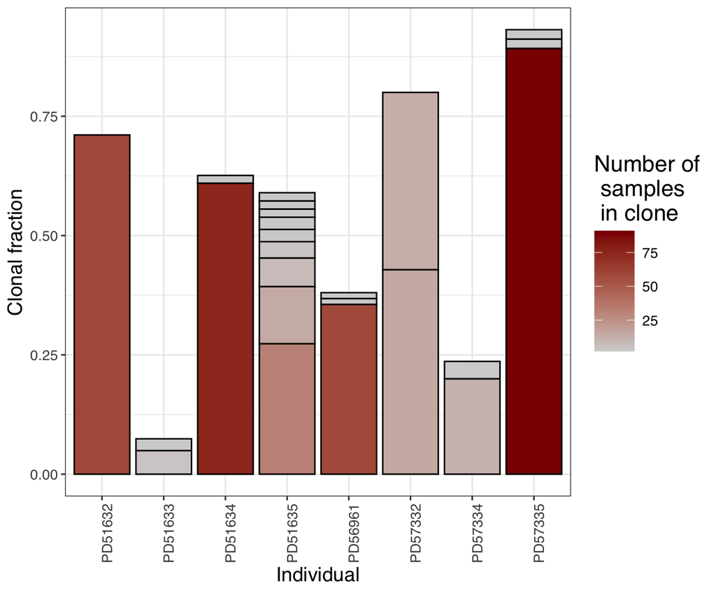

```r
dataset="CML"
dataset_mito_data<-all_mito_datasets[[dataset]]

### Basic plot to show a simplified clonal structure ----
expanded.clades.plot<-dplyr::bind_rows(Map(list=dataset_mito_data,exp_ID=names(dataset_mito_data),function(list,exp_ID){
  exp_nodes<-get_expanded_clade_nodes(list$tree.ultra,height_cut_off = ifelse(dataset=="NW",50,ifelse(dataset=="CML",2,200)),min_clonal_fraction=0.01,min_samples = 2)
  if(nrow(exp_nodes)==0) {stop(return(NULL))}
  exp_nodes$exp_ID<-exp_ID
  return(exp_nodes)
}))%>%
  arrange(desc(n_samples))%>%
  ggplot(aes(x=exp_ID,y=clonal_fraction,fill=n_samples))+
  geom_bar(stat="identity",position="stack",col="black")+
  scale_fill_gradient(low="lightgrey",high="darkred")+
  labs(x="Individual",y="Clonal fraction",fill="Number of\n samples\n in clone")+
  theme_bw()+
  my_markdown_theme+
  theme(axis.text.x=element_text(angle=90))
expanded.clades.plot
```

```r
save_plot(filename=paste0(plots_dir,dataset,"_expanded_clades_plot.pdf"),expanded.clades.plot,width=4,height=2.5)
```

#### Get info on ‘marker mutations’

For the previously selected dataset, find the best “marker mutations” and visualize this.

```r
expanded_clades_df<-Map(list=dataset_mito_data,exp_ID=names(dataset_mito_data),function(list,exp_ID){
  cat(paste0(exp_ID,"\n"))

  vaf.filt<-list$matrices$vaf.filt

  #Review how many expanded clades have reliable mitochondrial marker mutations
  marker_mut_cutoff<-0.03
  pos_mut_cutoff<-0.03
  exp_nodes<-get_expanded_clade_nodes(list$tree,height_cut_off = ifelse(dataset=="NW",50,200),min_clonal_fraction=0.01,min_samples = 2)
  if(nrow(exp_nodes)==0|is.null(list$shared_muts_df)) {stop(return(NULL))}
  full_df<-dplyr::bind_cols(data.frame(exp_ID=rep(exp_ID,nrow(exp_nodes))),
                            exp_nodes,
                            data.frame(marker_mut_cutoff=rep(marker_mut_cutoff,nrow(exp_nodes))),
                            exp_nodes_muts<-dplyr::bind_rows(lapply(exp_nodes$nodes,function(node) {
                              cat(node,sep="\n")
                              node_samples=getTips(list$tree,node)
                              if(any(vaf.filt[,node_samples]>marker_mut_cutoff)){

                                #Get mutations that are present in at least one sample in the clade above the 'marker_mut' VAF cutoff
                                node_homo_muts<-names(rowSums(vaf.filt[,node_samples,drop=F]>marker_mut_cutoff,na.rm=T)[rowSums(vaf.filt[,node_samples,drop=F]>marker_mut_cutoff)>0])

                                #Test samples outside the node - exclude if mutation is also present in a significant proportion of samples outside the node in question
                                #This will primarily exclude mutations that are high level oocyte heteroplasmies that are not informative
                                outside_node_samples<-list$tree$tip.label[!list$tree$tip.label%in%node_samples]
                                pos_outside_node_samples<-rowSums(vaf.filt[node_homo_muts,outside_node_samples,drop=F]>marker_mut_cutoff)
                                prop_pos_outside_node_samples<-pos_outside_node_samples/length(outside_node_samples)
                                node_homo_muts<-node_homo_muts[prop_pos_outside_node_samples<0.2]

                                if(length(node_homo_muts)==0) {
                                  stop(return(data.frame(nmuts=0,homo_muts=NA,pos_samples_per_mut=NA,max_pos_samples=0,max_pos_prop=0,mean_heteroplasmy=NA)))
                                }

                                pos_samples_per_mut<-sapply(node_homo_muts,function(mut){
                                  n_samples<-sum(vaf.filt[mut,node_samples,drop=F]>pos_mut_cutoff)
                                  return(n_samples)
                                })

                                mean_het_of_pos<-sapply(node_homo_muts,function(mut){
                                  pos_samples<-node_samples[vaf.filt[mut,node_samples]>pos_mut_cutoff]
                                  return(mean(as.numeric(vaf.filt[mut,pos_samples])))
                                })

                                return(data.frame(nmuts=length(node_homo_muts),
                                                  homo_muts=paste0(node_homo_muts,collapse=","),
                                                  BMM=node_homo_muts[which.max(pos_samples_per_mut)],
                                                  pos_samples_per_mut=paste0(pos_samples_per_mut,collapse=","),
                                                  max_pos_samples=max(pos_samples_per_mut,na.rm=T),
                                                  max_pos_prop=max(pos_samples_per_mut,na.rm=T)/length(node_samples),
                                                  mean_heteroplasmy=mean(as.numeric(vaf.filt[node_homo_muts[which.max(pos_samples_per_mut)],node_samples])),
                                                  mean_het_of_pos=mean_het_of_pos[which.max(pos_samples_per_mut)]))
                              } else {
                                return(data.frame(nmuts=0,homo_muts=NA,pos_samples_per_mut=NA,max_pos_samples=0,max_pos_prop=0,mean_heteroplasmy=NA))
                              }
                            })))
  #return(dplyr::select(full_df,-homo_muts,-pos_samples_per_mut))
  return(full_df)
})%>%dplyr::bind_rows()
```

```
## PD57334
## 61
## 73
## PD56961
## 242
## PD57335
## 107
## 181
## 182
## PD51634
## 129
## 212
## PD51633
## 96
## 117
## PD51632
## 87
## PD51635
## 125
## 136
## 139
## 164
## 170
## 175
## 181
## 212
## 219
## PD57332
```

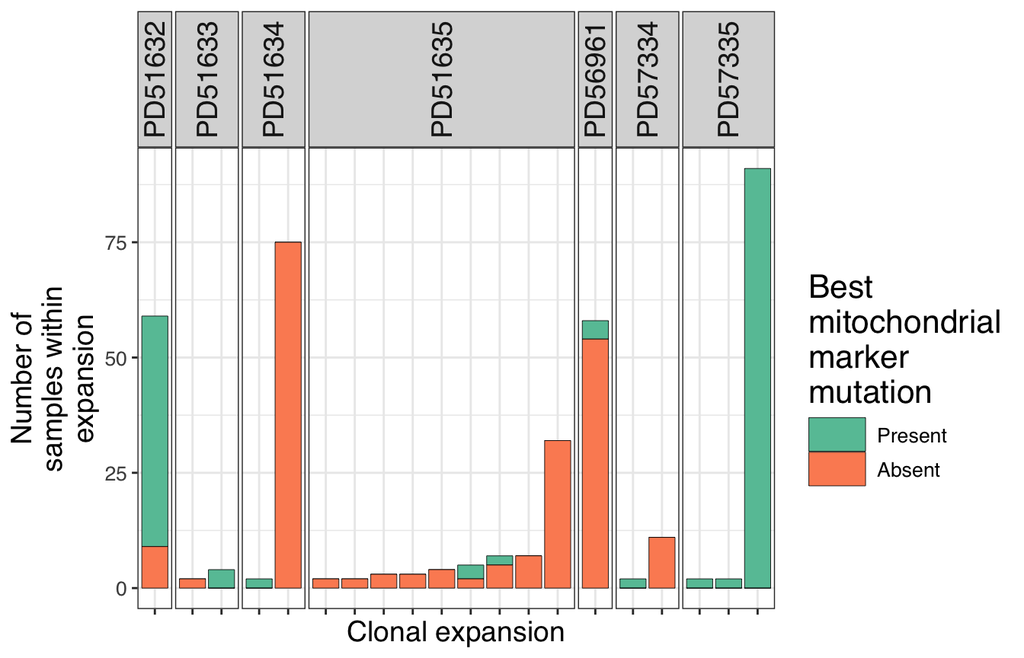

```r
node_factor_levels=expanded_clades_df%>%arrange(n_samples)%>%mutate(levels=stringr::str_c(exp_ID,nodes,sep = "_"))%>%pull(levels)
expanded.clades.marking.plot<-expanded_clades_df%>%
  mutate(n_neg_samples=n_samples-max_pos_samples)%>%
  dplyr::select(exp_ID,nodes,n_samples,max_pos_samples,n_neg_samples)%>%
  mutate(max_pos_samples=ifelse(max_pos_samples<=1,0,max_pos_samples))%>%
  mutate(n_neg_samples=n_samples-max_pos_samples)%>%
  tidyr::gather(-exp_ID,-nodes,-n_samples,key="Pos_or_neg",value="n_samples")%>%
  mutate(Pos_or_neg=ifelse(Pos_or_neg=="n_neg_samples","Absent","Present"))%>%
  mutate(Pos_or_neg=factor(Pos_or_neg,levels=c("Present","Absent")))%>%
  mutate(levels=str_c(exp_ID,nodes,sep = "_"))%>%
  ggplot(aes(x=factor(levels,levels=node_factor_levels),y=n_samples,fill=Pos_or_neg))+
  geom_bar(position="stack",stat="identity",col="black",linewidth=0.15)+
  scale_fill_brewer(palette="Set2")+
  facet_grid(~exp_ID,scales="free",space = "free")+
  #scale_y_continuous(breaks=seq(0,10,2))+
  theme_bw()+
  my_markdown_theme+
  theme(panel.spacing=unit(0.5,"mm"),axis.text.x = element_blank(),strip.text.x = element_text(angle=90))+
  labs(x="Clonal expansion",y=str_wrap("Number of samples within expansion",width=15),fill=str_wrap("Best mitochondrial marker mutation",width=10))

expanded.clades.marking.plot
```

```r
save_plot(filename=paste0(plots_dir,"expanded_clades_marking_plot_",dataset,".pdf"),expanded.clades.marking.plot,width=7,height=2.3)
```

```r
expanded_clades_df$n_marker<-sapply(1:nrow(expanded_clades_df),function(i) {
  pos_samples_per_mut<-as.numeric(stringr::str_split(expanded_clades_df$pos_samples_per_mut[i],pattern = ",")[[1]])
  n_perfect_markers<-sum(pos_samples_per_mut==expanded_clades_df$n_samples[i])
  return(n_perfect_markers)
})
```

## COPY NUMBER ANALYSIS

Analyse the mitochondrial DNA copy number, by individual.

Here we have a boxplot of the mtDNA copy number for each individual as a boxplot. The boxplots are grouped by their tissue of origin. Note that the y-axis is logarithmic as there is huge between sample variability (both within and between tissues).

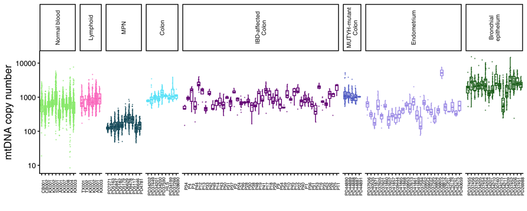

```r
#Box plots of copy number by tissue type
cn_by_tissue_plot<-mito_cn%>%
  filter(Tissue%in%translate$al_ref)%>%
  right_join(sample_summary_info,by=c("Sample"="SampleID"))%>%
  mutate(Tissue=factor(name_conversion_vec[dataset],levels=name_conversion_vec))%>%
  filter(!is.na(bedtools_mtDNA_genomes))%>%
  ggplot(aes(x=factor(exp_ID,levels=ref_df%>%arrange(Age)%>%pull(ID)%>%unique()),y=bedtools_mtDNA_genomes,col=Tissue))+
  geom_boxplot(outlier.shape = NA)+
  geom_jitter(width=0.1,alpha=0.5,size=0.2)+
  scale_color_manual(values=tissue_cols)+
  scale_y_log10()+
  facet_grid(~Tissue,scales="free",space="free")+
  theme_classic()+
  my_markdown_theme+
  #Tissue panels are sized by sample count (space="free"), so the narrow ones cannot
  #fit a horizontal label - rotate the strips so the label length is limited by panel
  #height rather than width, as done for the per-donor facets elsewhere in this notebook.
  theme(axis.text.x=element_text(angle=90,size = 6),legend.position="none",
        strip.text.x = element_text(angle=90,size = 8))+
  labs(x="",y="mtDNA copy number")
cn_by_tissue_plot
```

```r
save_plot(filename=paste0(plots_dir,"cn_by_tissue_plot.pdf"),cn_by_tissue_plot,width=10,height=4)
```

Given that tissue type is a major driver of mtDNA copy number, summarise this by group all samples from a given tissue (aggregating across individuals) into a single ridge plot.

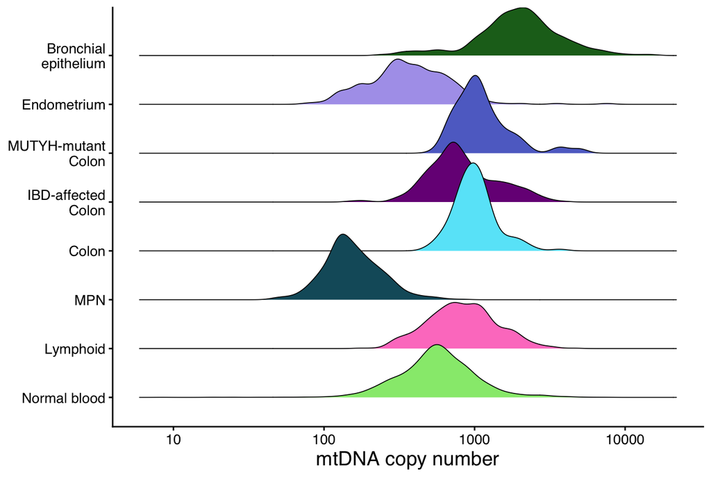

```r
#Ridges plots of copy number distribution across the tissue
mitoCN_ridges_plot<-mito_cn%>%
  filter(Tissue%in%translate$al_ref)%>%
  right_join(sample_summary_info,by=c("Sample"="SampleID"))%>%
  mutate(Tissue=factor(name_conversion_vec[dataset],levels=name_conversion_vec))%>%
  filter(!is.na(bedtools_mtDNA_genomes))%>%
  mutate(log_mitoCN=log(bedtools_mtDNA_genomes))%>%
  ggplot(aes(y=Tissue,x=bedtools_mtDNA_genomes,fill=Tissue))+
  ggridges::geom_density_ridges(linewidth=0.3)+
  scale_fill_manual(values=tissue_cols)+
  scale_x_log10()+
  theme_classic()+
  my_markdown_theme+
  theme(legend.position="none",axis.title.y=element_blank())+
  labs(x="mtDNA copy number")
mitoCN_ridges_plot
```

```r
save_plot(filename=paste0(plots_dir,"mitoCN_ridges_plot.pdf"),mitoCN_ridges_plot,width=3,height=2)
```

Within each tissue, is there a difference in copy number through life? No - nothing convincing.

```r
#Dot plot of median copy number against age, points coloured by tissue plot
#There are overlying regression lines to show the relationship against age
median_cn_by_age_plot<-mito_cn%>%
  filter(Tissue%in%translate$al_ref)%>%
  right_join(sample_summary_info,by=c("Sample"="SampleID"))%>%
  mutate(Tissue=factor(name_conversion_vec[dataset],levels=name_conversion_vec))%>%
  filter(!is.na(bedtools_mtDNA_genomes))%>%
  group_by(Tissue,exp_ID)%>%
  dplyr::summarise(Tissue=Tissue[1],median_cn=median(bedtools_mtDNA_genomes))%>%
  left_join(ref_df,by=c("exp_ID"="ID"),relationship="many-to-many")%>%
  ggplot(aes(x=Age,y=median_cn,col=Tissue))+
  geom_point(size=0.5)+
  scale_color_manual(values=tissue_cols)+
  geom_smooth(method="lm",linewidth=0.75,alpha=0.3)+
  scale_y_log10()+
  theme_classic()+
  my_markdown_theme+
  theme(legend.position="right")+
  labs(x="Age",y="mtDNA copy number")
```

```
## `summarise()` has regrouped the output.
## ℹ Summaries were computed grouped by Tissue and exp_ID.
## ℹ Output is grouped by Tissue.
## ℹ Use `summarise(.groups = "drop_last")` to silence this message.
## ℹ Use `summarise(.by = c(Tissue, exp_ID))` for per-operation grouping
##   (`?dplyr::dplyr_by`) instead.
```

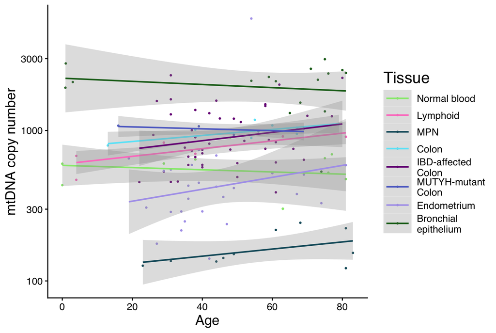

```r
median_cn_by_age_plot
```

```r
save_plot(filename=paste0(plots_dir,"median_cn_by_age_plot.pdf"),median_cn_by_age_plot,width=3.3,height=2)
```

Mean copy number by tissue. Given the log-normal distribution, perform the means on the log-transformed data then transform back to absolute numbers.

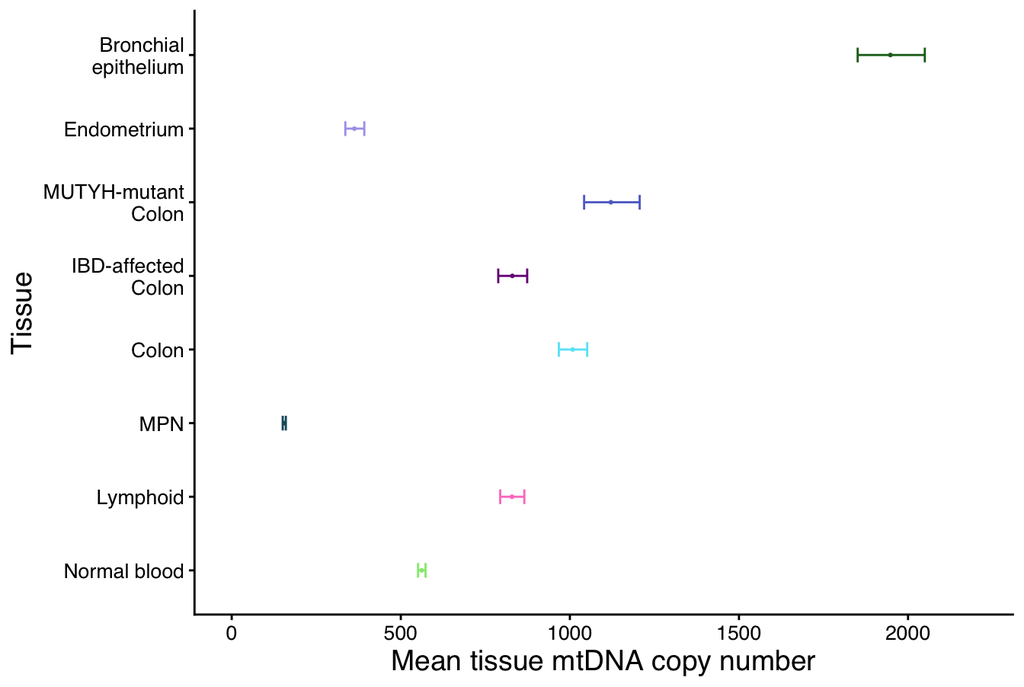

```r
mean_cn_plot<-mito_cn%>%
  filter(Tissue%in%translate$al_ref)%>%
  right_join(sample_summary_info,by=c("Sample"="SampleID"))%>%
  mutate(Tissue=factor(name_conversion_vec[dataset],levels=name_conversion_vec))%>%
  filter(!is.na(bedtools_mtDNA_genomes))%>%
  group_by(Tissue)%>%
  dplyr::summarise(n=n(),
                   mean_cn=mean(bedtools_mtDNA_genomes),
                   var_cn=var(bedtools_mtDNA_genomes),
                   sd_cn=sd(bedtools_mtDNA_genomes),
                   mean_logCN=mean(log(bedtools_mtDNA_genomes)),
                   var_logCN=var(log(bedtools_mtDNA_genomes)),
                   sd_logCN=sd(log(bedtools_mtDNA_genomes)))%>%
  dplyr::mutate(sem_logCN=sd_logCN/sqrt(n))%>%
  dplyr::mutate(lowerCI_mean_logCN=mean_logCN-(1.96*sem_logCN),upperCI_mean_logCN=mean_logCN+(1.96*sem_logCN))%>%
  dplyr::mutate(mean_cn2=exp(mean_logCN),lowerCI_mean_CN=exp(lowerCI_mean_logCN),upperCI_mean_CN=exp(upperCI_mean_logCN))%>%
  dplyr::select(Tissue,mean_cn,mean_cn2,lowerCI_mean_CN,upperCI_mean_CN)%>%
  ggplot(aes(y=Tissue,x=mean_cn2,xmin=lowerCI_mean_CN,xmax=upperCI_mean_CN,col=Tissue))+
  geom_point(size=0.4)+
  geom_errorbar(width=0.2)+
  scale_x_continuous(limits=c(0,2200))+
  scale_color_manual(values=tissue_cols)+
  theme_classic()+
  my_markdown_theme+
  labs(x="Mean tissue mtDNA copy number")+
  theme(legend.position="none")
mean_cn_plot
```

```r
save_plot(filename=paste0(plots_dir,"mean_cn_plot.pdf"),mean_cn_plot,width=3,height=2)
```

Create a dataframe to use with the linear mixed effects model.

```r
mito_cn_lmer_df<-mito_cn%>%
  filter(Tissue%in%translate$al_ref)%>%
  right_join(sample_summary_info,by=c("Sample"="SampleID"))%>%
  mutate(Tissue=factor(name_conversion_vec[dataset],levels=name_conversion_vec))%>%
  filter(!is.na(bedtools_mtDNA_genomes))%>%
  mutate(log_mitoCN=log(bedtools_mtDNA_genomes))%>%
  left_join(ref_df%>%dplyr::select(ID,Age,Smoking_years)%>%filter(!duplicated(.)),by=c("exp_ID"="ID"))
```

Given that CN is a log-normal distribution, do the model against log CN

```r
#LMER MODEL 1: LMER of logCN against Age and Tissue
mito_cn.lmer_with_age<-lmerTest::lmer(log_mitoCN~Age+Tissue+(1|exp_ID),data=mito_cn_lmer_df)
summary(mito_cn.lmer_with_age)
```

```
## Linear mixed model fit by REML. t-tests use Satterthwaite's method [
## lmerModLmerTest]
## Formula: log_mitoCN ~ Age + Tissue + (1 | exp_ID)
##    Data: mito_cn_lmer_df
##
## REML criterion at convergence: 9853.4
##
## Scaled residuals:
##     Min      1Q  Median      3Q     Max
## -8.6720 -0.5511 -0.0172  0.5621  5.4988
##
## Random effects:
##  Groups   Name        Variance Std.Dev.
##  exp_ID   (Intercept) 0.1293   0.3596
##  Residual             0.2477   0.4977
## Number of obs: 6610, groups:  exp_ID, 123
##
## Fixed effects:
##                               Estimate Std. Error         df t value Pr(>|t|)
## (Intercept)                  6.135e+00  1.284e-01  8.572e+01  47.768  < 2e-16
## Age                          3.026e-03  1.748e-03  9.441e+01   1.731 0.086725
## TissueLymphoid               5.809e-01  2.634e-02  6.563e+03  22.055  < 2e-16
## TissueMPN                   -1.228e+00  1.581e-01  7.911e+01  -7.765 2.48e-11
## TissueColon                  6.228e-01  1.665e-01  8.798e+01   3.742 0.000325
## TissueIBD-affected\nColon    4.497e-01  1.222e-01  8.749e+01   3.679 0.000404
## TissueMUTYH-mutant\nColon    7.352e-01  2.033e-01  9.034e+01   3.616 0.000492
## TissueEndometrium           -2.529e-01  1.310e-01  8.993e+01  -1.931 0.056659
## TissueBronchial\nepithelium  1.315e+00  1.427e-01  8.123e+01   9.214 2.92e-14
##
## (Intercept)                 ***
## Age                         .
## TissueLymphoid              ***
## TissueMPN                   ***
## TissueColon                 ***
## TissueIBD-affected\nColon   ***
## TissueMUTYH-mutant\nColon   ***
## TissueEndometrium           .
## TissueBronchial\nepithelium ***
## ---
## Signif. codes:  0 '***' 0.001 '**' 0.01 '*' 0.05 '.' 0.1 ' ' 1
##
## Correlation of Fixed Effects:
##             (Intr) Age    TssLym TssMPN TssCln TIBD-C TMUTYC TssEnd
## Age         -0.573
## TissuLymphd -0.060  0.022
## TissueMPN   -0.454 -0.161  0.035
## TissueColon -0.458 -0.105  0.034  0.438
## TssIBD-ffcC -0.672 -0.059  0.048  0.583  0.551
## TssMUTYH-mC -0.418 -0.011  0.030  0.347  0.329  0.447
## TissEndmtrm -0.655 -0.007  0.046  0.536  0.509  0.693  0.416
## TssBrnchlep -0.497 -0.188  0.038  0.522  0.487  0.647  0.384  0.595
```

```r
confint(mito_cn.lmer_with_age)
```

```
## Computing profile confidence intervals ...
```

```
##                                     2.5 %       97.5 %
## .sig01                       0.2945759235  0.402743569
## .sigma                       0.4892532868  0.506398910
## (Intercept)                  5.8923092033  6.379717458
## Age                         -0.0003122265  0.006330397
## TissueLymphoid               0.5290288226  0.632288319
## TissueMPN                   -1.5273035906 -0.928060087
## TissueColon                  0.3069302421  0.938623184
## TissueIBD-affected\nColon    0.2173543190  0.681256421
## TissueMUTYH-mutant\nColon    0.3494503326  1.121173321
## TissueEndometrium           -0.5033236957 -0.005719495
## TissueBronchial\nepithelium  1.0438022331  1.584676823
```

```r
#LMER MODEL 2: Given no convincing age relationship, do LMER of logCN against tissue only
mito_cn.lmer<-lme4::lmer(log_mitoCN~Tissue+(1|exp_ID),data=mito_cn_lmer_df)
summary(mito_cn.lmer)
```

```
## Linear mixed model fit by REML ['lmerMod']
## Formula: log_mitoCN ~ Tissue + (1 | exp_ID)
##    Data: mito_cn_lmer_df
##
## REML criterion at convergence: 9845.6
##
## Scaled residuals:
##     Min      1Q  Median      3Q     Max
## -8.6708 -0.5544 -0.0167  0.5626  5.4998
##
## Random effects:
##  Groups   Name        Variance Std.Dev.
##  exp_ID   (Intercept) 0.1313   0.3623
##  Residual             0.2477   0.4977
## Number of obs: 6610, groups:  exp_ID, 123
##
## Fixed effects:
##                             Estimate Std. Error t value
## (Intercept)                  6.26223    0.10604  59.055
## TissueLymphoid               0.58002    0.02634  22.023
## TissueMPN                   -1.18335    0.15715  -7.530
## TissueColon                  0.65320    0.16667   3.919
## TissueIBD-affected\nColon    0.46230    0.12287   3.763
## TissueMUTYH-mutant\nColon    0.73897    0.20466   3.611
## TissueEndometrium           -0.25070    0.13186  -1.901
## TissueBronchial\nepithelium  1.36105    0.14111   9.645
##
## Correlation of Fixed Effects:
##             (Intr) TssLym TssMPN TssCln TIBD-C TMUTYC TssEnd
## TissuLymphd -0.057
## TissueMPN   -0.675  0.039
## TissueColon -0.636  0.036  0.429
## TssIBD-ffcC -0.863  0.049  0.582  0.549
## TssMUTYH-mC -0.518  0.030  0.350  0.330  0.447
## TissEndmtrm -0.804  0.046  0.543  0.512  0.694  0.417
## TssBrnchlep -0.751  0.043  0.507  0.478  0.649  0.389  0.604
```

```r
lmer.CIs<-confint(mito_cn.lmer)
```

```
## Computing profile confidence intervals ...
```

```r
#Do AIC on model 1 and 2 to give
m1<-lme4::lmer(log_mitoCN~Age+Tissue+(1|exp_ID),data=mito_cn_lmer_df,REML = F)
m2<-lme4::lmer(log_mitoCN~Tissue+(1|exp_ID),data=mito_cn_lmer_df,REML = F)

#What is the improvement in the AIC?
diff(AIC(m1,m2)$AIC)
```

```
## [1] 1.158353
```

LMER MODEL 3: See if bronchial CN correlates with smoking status?

No significant correlation in our data. However, this may be confounded by the in vitro colony formation or the fact that these are purified epithelial cell.

```r
mito_cn.lmer_lung_smoking<-lme4::lmer(log_mitoCN~Smoking_years+(1|exp_ID),data=mito_cn_lmer_df%>%filter(dataset=="KY")%>%mutate(Smoking_years=as.numeric(Smoking_years))%>%replace_na(replace = list(Smoking_years=0)))
summary(mito_cn.lmer_lung_smoking)
```

```
## Linear mixed model fit by REML ['lmerMod']
## Formula: log_mitoCN ~ Smoking_years + (1 | exp_ID)
##    Data:
## mito_cn_lmer_df %>% filter(dataset == "KY") %>% mutate(Smoking_years = as.numeric(Smoking_years)) %>%
##     replace_na(replace = list(Smoking_years = 0))
##
## REML criterion at convergence: 1070.5
##
## Scaled residuals:
##     Min      1Q  Median      3Q     Max
## -4.2990 -0.5872 -0.1101  0.5359  3.4510
##
## Random effects:
##  Groups   Name        Variance Std.Dev.
##  exp_ID   (Intercept) 0.1411   0.3756
##  Residual             0.2910   0.5395
## Number of obs: 632, groups:  exp_ID, 16
##
## Fixed effects:
##                Estimate Std. Error t value
## (Intercept)    7.684106   0.141601  54.266
## Smoking_years -0.002270   0.003835  -0.592
##
## Correlation of Fixed Effects:
##             (Intr)
## Smoking_yrs -0.730
```

```r
confint(mito_cn.lmer_lung_smoking)
```

```
## Computing profile confidence intervals ...
```

```
##                      2.5 %      97.5 %
## .sig01         0.249027870 0.527113165
## .sigma         0.510686455 0.571042737
## (Intercept)    7.408216964 7.960266108
## Smoking_years -0.009732441 0.005217324
```

To visualize the different tissue effects on mtDNA copy number, show the tissue co-efficients from the LME model. This initial visualization shows the log values.

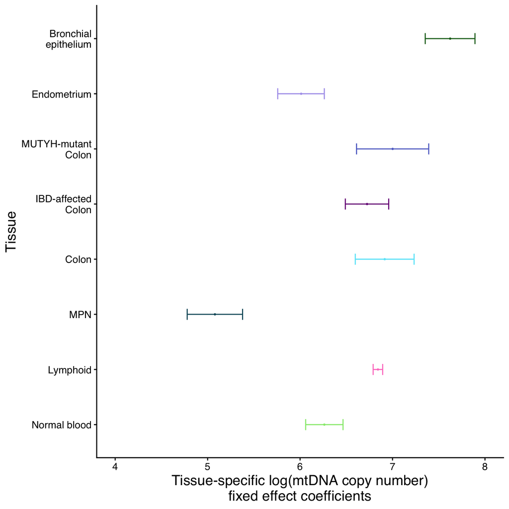

```r
#Visualize the LMER MODEL 2 tissue-specific coefficients
intercept_value<-summary(mito_cn.lmer)$coefficients["(Intercept)","Estimate"]
tissue_lmer_coefs_plot<-as.data.frame(summary(mito_cn.lmer)$coefficients)%>%
  tibble::rownames_to_column(var="Tissue")%>%
  left_join(as.data.frame(lmer.CIs)%>%tibble::rownames_to_column(var="Tissue"))%>%
  dplyr::select(Tissue,Estimate,lowerCI=`2.5 %`,upperCI=`97.5 %`)%>%
  mutate(Estimate=ifelse(grepl("Tissue",Tissue),Estimate+intercept_value,Estimate),
         lowerCI=ifelse(grepl("Tissue",Tissue),lowerCI+intercept_value,lowerCI),
         upperCI=ifelse(grepl("Tissue",Tissue),upperCI+intercept_value,upperCI))%>%
  filter(Tissue!="Age")%>%
  mutate(Tissue=ifelse(Tissue=="(Intercept)","Normal blood",gsub("Tissue","",Tissue)))%>%
  mutate(Tissue=factor(Tissue,levels=name_conversion_vec))%>%
  #mutate_at(c("Estimate","lowerCI","upperCI"),function(x) {exp(x)})%>%
  ggplot(aes(y=Tissue,x=Estimate,xmin=lowerCI,xmax=upperCI,col=Tissue))+
  geom_point(size=0.4)+
  geom_errorbar(width=0.2)+
  scale_x_continuous(limits=c(4,8))+
  #scale_x_continuous(limits=c(0,2300))+
  scale_color_manual(values=tissue_cols)+
  theme_classic()+
  my_markdown_theme+
  labs(x="Tissue-specific log(mtDNA copy number)\nfixed effect coefficients")+
  theme(legend.position="none")
tissue_lmer_coefs_plot
```

```r
save_plot(filename=paste0(plots_dir,"tissue_lmer_coefs_plot.pdf"),tissue_lmer_coefs_plot,width=3,height=2)
```

Here, convert back to the absolute values. This is essentially like doing a regression on the geometric mean mtDNA value.

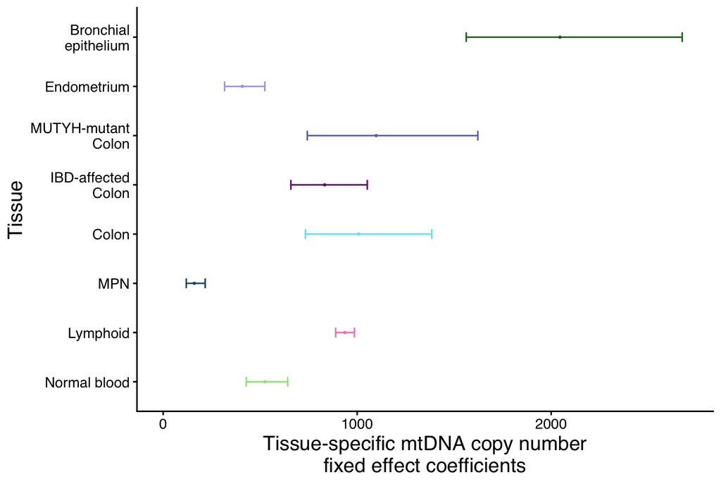

```r
#Visualize the LMER MODEL 2 tissue-specific coefficients - now transformed back to absolute scale
intercept_value<-summary(mito_cn.lmer)$coefficients["(Intercept)","Estimate"]
tissue_lmer_exp_coefs_plot<-as.data.frame(summary(mito_cn.lmer)$coefficients)%>%
  tibble::rownames_to_column(var="Tissue")%>%
  left_join(as.data.frame(lmer.CIs)%>%tibble::rownames_to_column(var="Tissue"),by="Tissue")%>%
  dplyr::select(Tissue,Estimate,lowerCI=`2.5 %`,upperCI=`97.5 %`)%>%
  mutate(Estimate=ifelse(grepl("Tissue",Tissue),Estimate+intercept_value,Estimate),
         lowerCI=ifelse(grepl("Tissue",Tissue),lowerCI+intercept_value,lowerCI),
         upperCI=ifelse(grepl("Tissue",Tissue),upperCI+intercept_value,upperCI))%>%
  filter(Tissue!="Age")%>%
  mutate(Tissue=ifelse(Tissue=="(Intercept)","Normal blood",gsub("Tissue","",Tissue)))%>%
  mutate(Tissue=factor(Tissue,levels=name_conversion_vec))%>%
  mutate_at(c("Estimate","lowerCI","upperCI"),function(x) {exp(x)})%>%
  ggplot(aes(y=Tissue,x=Estimate,xmin=lowerCI,xmax=upperCI,col=Tissue))+
  geom_point(size=0.4)+
  geom_errorbar(width=0.2)+
  scale_x_continuous(limits=c(0,2700))+
  scale_color_manual(values=tissue_cols)+
  theme_classic()+
  my_markdown_theme+
  labs(x="Tissue-specific mtDNA copy number\nfixed effect coefficients")+
  theme(legend.position="none")
tissue_lmer_exp_coefs_plot
```

```r
save_plot(filename=paste0(plots_dir,"tissue_lmer_exp_coefs_plot.pdf"),tissue_lmer_exp_coefs_plot,width=3,height=2)
```

# MUTATIONAL PROFILES - 96-profile plots

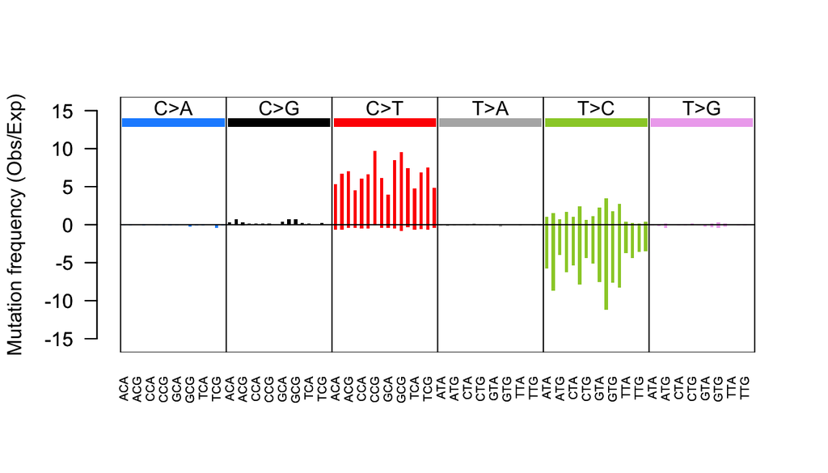

```r
trinucleotide_plot(mutations = all_df_tidy[all_cohorts]%>%
                     dplyr::bind_rows()%>%
                     filter(Sample!="global"&
                              !mut_ref%in%exclude_muts)%>%
                     separate(mut_ref,into=c("chr","pos","ref","mut"))%>%
                     dplyr::rename("donor"=exp_ID)%>%
                     mutate(pos=as.numeric(pos)),
                   analysis_region = "all_mtDNA",
                   analysis_type = "obs_exp",
                   file_name = plot_file(paste0(plots_dir,"Mutational_signature_nonblood_all.pdf")))
```

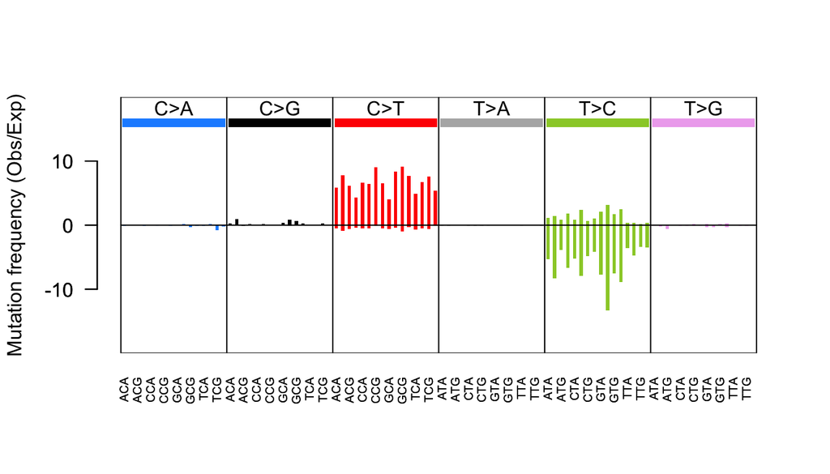

```r
#Low-VAF profile: cut at 0.1, matching the output file name and the published
#Extended Data Fig. 3d ("<10%"). This filter previously read vaf<0.05.
trinucleotide_plot(mutations = all_df_tidy[all_cohorts]%>%
                     dplyr::bind_rows()%>%
                     filter(Sample!="global"&
                              !mut_ref%in%exclude_muts&
                              vaf<0.1)%>%
                     separate(mut_ref,into=c("chr","pos","ref","mut"))%>%
                     dplyr::rename("donor"=exp_ID)%>%
                     mutate(pos=as.numeric(pos)),
                   analysis_region = "all_mtDNA",
                   analysis_type = "obs_exp",
                   file_name = plot_file(paste0(plots_dir,"Mutational_signature_non_blood_under0.1.pdf")))
```

# MUTATION BURDENS

Print stats for total mutation numbers.

```r
mutCN_cutoff=25 #If the mitochondrial copy number is over 25, retain mutation even if is in the "CN correlating muts" list
vaf_cut_off<-0.03
rho_cut_off<-0
temp=Map(dataset_mito_data=all_mito_datasets[all_cohorts],dataset=all_cohorts, function(dataset_mito_data,dataset) {

  #Total number of SNVs identified by shearwater - this includes the heterozygous oocyte mutations
  SW_total<-sum(unlist(lapply(dataset_mito_data,function(list) {
    if(is.null(list)){stop(return(NULL))}
    vaf.filt<-(list$matrices$vaf*list$matrices$SW)[!grepl("DEL|INS",rownames(list$matrices$vaf))&
                                                     list$rho_vals>rho_cut_off&
                                                     !rownames(list$matrices$vaf)%in%exclude_muts,list$tree$tip.label]
    total_pos=rowSums(vaf.filt>=vaf_cut_off,na.rm = T)
    return(sum(total_pos>0,na.rm=T))
  })))

  #Total number of SNVs identified by shearwater - once CN correlating muts excluded
  SW_total_CN_excluded<-sum(unlist(lapply(dataset_mito_data,function(list) {
    if(is.null(list)){stop(return(NULL))}
    CN_correlating_mut_removal_mat=list$matrices$implied_mutCN>mutCN_cutoff|(matrix((!rownames(list$matrices$vaf)%in%dataset_mito_data$CN_correlating_muts),ncol=1)%*%matrix(rep(1,ncol(list$matrices$vaf)),nrow=1))
    vaf.filt<-(list$matrices$vaf*list$matrices$SW*CN_correlating_mut_removal_mat)[!grepl("DEL|INS",rownames(list$matrices$vaf))&
                                                                                    list$rho_vals>rho_cut_off&
                                                                                    !rownames(list$matrices$vaf)%in%exclude_muts,list$tree$tip.label]
    total_pos=rowSums(vaf.filt>=vaf_cut_off,na.rm = T)
    return(sum(total_pos>0,na.rm=T))
  })))

  cat(paste("Print stats for",dataset),sep="\n")
  cat(paste("There are",SW_total,"that pass shearwater in at least one sample"),sep="\n")
  cat(paste("There are",SW_total_CN_excluded,"that pass shearwater in at least one sample, after copy-number correlating mutations are excluded"),sep="\n")

})
```

```
## Print stats for KY
## There are 813 that pass shearwater in at least one sample
## There are 813 that pass shearwater in at least one sample, after copy-number correlating mutations are excluded
## Print stats for HL
## There are 449 that pass shearwater in at least one sample
## There are 449 that pass shearwater in at least one sample, after copy-number correlating mutations are excluded
## Print stats for SO
## There are 589 that pass shearwater in at least one sample
## There are 589 that pass shearwater in at least one sample, after copy-number correlating mutations are excluded
## Print stats for PR
## There are 211 that pass shearwater in at least one sample
## There are 211 that pass shearwater in at least one sample, after copy-number correlating mutations are excluded
## Print stats for LM
## There are 406 that pass shearwater in at least one sample
## There are 406 that pass shearwater in at least one sample, after copy-number correlating mutations are excluded
## Print stats for NW
## There are 1261 that pass shearwater in at least one sample
## There are 1261 that pass shearwater in at least one sample, after copy-number correlating mutations are excluded
## Print stats for lymph
## There are 445 that pass shearwater in at least one sample
## There are 445 that pass shearwater in at least one sample, after copy-number correlating mutations are excluded
## Print stats for blood
## There are 4814 that pass shearwater in at least one sample
## There are 4814 that pass shearwater in at least one sample, after copy-number correlating mutations are excluded
```

### Save ‘prop of samples with mut’ plots for each dataset

```r
#Compile list of 'passing' samples and donors
samples_per_individual=Map(dataset_mito_data=all_mito_datasets[all_cohorts],dataset=all_cohorts, function(dataset_mito_data,dataset) {
  Map(list=dataset_mito_data,exp_ID=names(dataset_mito_data),function(list,exp_ID){data.frame(exp_ID=exp_ID,Sample=list$tree$tip.label)})%>%
    dplyr::bind_rows()%>%
    dplyr::mutate(dataset=dataset)
})%>%dplyr::bind_rows()%>%group_by(dataset,exp_ID)%>%summarise(dataset=dataset[1],n=n())
```

```
## `summarise()` has regrouped the output.
## ℹ Summaries were computed grouped by dataset and exp_ID.
## ℹ Output is grouped by dataset.
## ℹ Use `summarise(.groups = "drop_last")` to silence this message.
## ℹ Use `summarise(.by = c(dataset, exp_ID))` for per-operation grouping
##   (`?dplyr::dplyr_by`) instead.
```

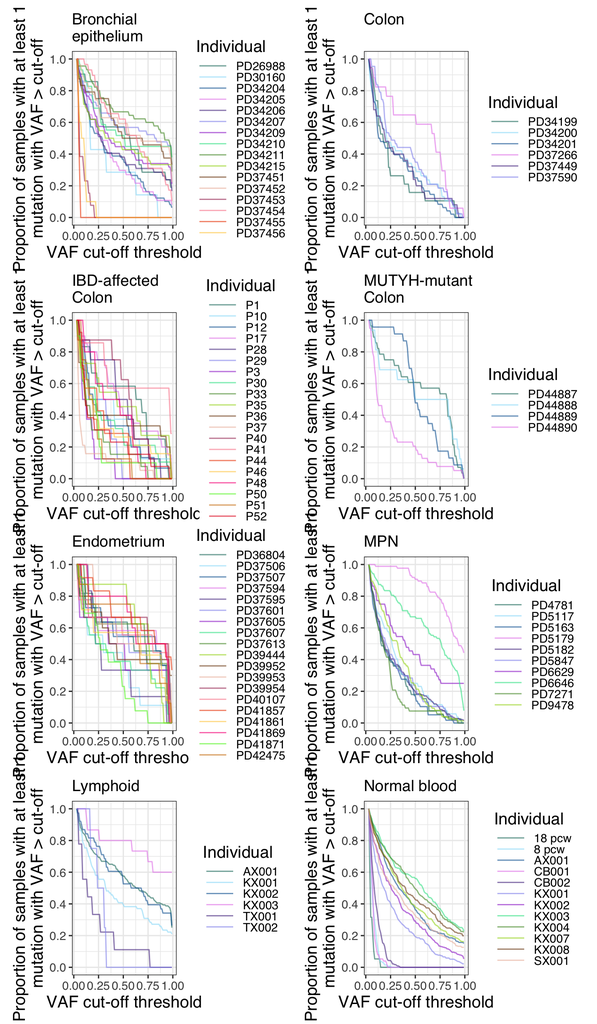

```r
#Do not do this for individuals with <8 samples
plot_list=Map(dataset_mito_data=all_mito_datasets[all_cohorts],df_tidy=all_df_tidy[all_cohorts],this_dataset=all_cohorts, function(dataset_mito_data,df_tidy,this_dataset) {

  min_samples_per_individual=8
  individuals_to_include<-samples_per_individual%>%filter(n>=min_samples_per_individual & dataset==this_dataset)%>%pull(exp_ID)
  exp_cols<-c("#aee39a", "#18786a", "#99def9", "#0362a0", "#e689eb", "#53348e", "#9296ee", "#9e37d0", "#32e195", "#50942f", "#a3d71e", "#7c440e", "#ecbcab", "#a53460", "#fb899b", "#ed4b04", "#ffce54", "#f82387", "#61f22d", "#d07d09","#E41A1C")
  names(exp_cols)<-c("Dummy_foetal",individuals_to_include)

  Individual_burden_means_df<-df_tidy%>%
    dplyr::filter(!mut_ref%in%exclude_muts)%>%
    group_by(Sample)%>%
    dplyr::summarise(exp_ID=unique(exp_ID),n_mut=sum(vaf>vaf_cut_off))%>%
    tidyr::complete(Sample,fill=list(n_mut=0))%>%
    group_by(exp_ID)%>%
    summarise(mean=mean(n_mut))

  samples_with_mut_df<-dplyr::bind_rows(lapply(seq(vaf_cut_off,0.99,0.01),function(cut_off) {
    cut_off_df<-df_tidy%>%
      group_by(Sample)%>%
      dplyr::summarise(exp_ID=exp_ID[1],n_mut=sum(vaf>cut_off))%>%
      tidyr::complete(Sample,fill=list(n_mut=0))%>%
      #left_join(dataset_sample_ref,by="Sample")%>%
      group_by(exp_ID)%>%
      dplyr::summarise(mean=mean(n_mut),n_with_mut=sum(n_mut>0),n_samp=n())%>%
      mutate(prop_with_mut=n_with_mut/n_samp,cut_off=cut_off)
    return(cut_off_df)
  }))

  prop.of.samples.with.mut<-samples_with_mut_df%>%
    filter(exp_ID%in%individuals_to_include)%>% #Only include individuals with at least 8 samples
    ggplot(aes(x=cut_off,y=prop_with_mut,col=factor(exp_ID)))+
    geom_line(alpha=0.6)+
    theme_bw()+
    scale_y_continuous(limits=c(0,1),breaks=seq(0,1,0.2))+
    scale_color_manual(values=exp_cols)+
    guides(colour = guide_legend(ncol=1))+
    labs(x="VAF cut-off threshold",
         y=str_wrap("Proportion of samples with at least 1 mutation with VAF > cut-off",width=40),
         col="Individual",title = name_conversion_vec[this_dataset])+
    my_markdown_theme+
    theme(legend.key.height = unit(2.8,"mm"),legend.title = element_text(size = 14))
  save_plot(filename=paste0(plots_dir,"Sample_proportions_with_mut_",this_dataset,".pdf"),prop.of.samples.with.mut,width=3.5,height=2)
  return(prop.of.samples.with.mut)
})
wrap_plots(plot_list,ncol=2)
```

### Get sum of vaf data for all datasets

```r
#Sum of VAF mutation burden measures
mutCN_cutoff=25 #If the mitochondrial copy number is over 25, retain mutation even if is in the "CN correlating muts" list
vaf_cut_off=0.03 #only include VAFs above a cutoff
all_sum_of_vaf_df=Map(dataset_mito_data=all_mito_datasets[all_cohorts],dataset=all_cohorts, function(dataset_mito_data,dataset) {
  cat(dataset,sep="\n")
  CN_correlating_muts<-dataset_mito_data$CN_correlating_muts
  sum_of_vaf_df<-Map(list=dataset_mito_data,Exp_ID=names(dataset_mito_data),function(list,Exp_ID){

    #sum the vaf of mutations that:
    #(1) Pass shearwater,
    #(2) are not indels, specific artefacts or 'copy number correlating mutations' (i.e. most likely artefacts from mismapping of nuclear DNA or low-level contamination)
    #(3) are not heteroplasmic oocyte mutations - if you have these, all cells have a 'headstart' in their mtDNA mutation acquisition; therefore no fair comparison

    CN_correlating_mut_removal_mat=list$matrices$implied_mutCN>mutCN_cutoff|(matrix((!rownames(list$matrices$vaf)%in%CN_correlating_muts),ncol=1)%*%matrix(rep(1,ncol(list$matrices$vaf)),nrow=1))

    df<-as.data.frame(colSums((list$matrices$vaf*(list$matrices$vaf>vaf_cut_off)*list$matrices$SW*(CN_correlating_mut_removal_mat))[!grepl("DEL|INS",rownames(list$matrices$vaf))&
                                                                                                                                      !rownames(list$matrices$vaf)%in%c(exclude_muts,list$het_oocyte_muts),list$tree$tip.label]))%>%
      tibble::rownames_to_column(var="Sample")%>%
      mutate(exp_ID=Exp_ID)%>%
      dplyr::rename(sum_of_vaf=2)

    return(df)
  })%>%dplyr::bind_rows()%>%
    mutate(dataset=dataset,.before=1)

  return(sum_of_vaf_df)
})%>%dplyr::bind_rows()
```

```
## KY
## HL
## SO
## PR
## LM
## NW
## lymph
## blood
```

### plot ‘sum of vaf’ data individually for all datasets

```r
dont_show_medians_tissues<-c("KY","LM","SO") #Too many individuals to print median values on the plot (gets too busy)

plot_list=lapply(all_cohorts,function(this_dataset) {
  cat(this_dataset,sep="\n")

  min_samples_per_individual=8
  sum_of_vaf_summary<-all_sum_of_vaf_df%>%
    filter(dataset==this_dataset)%>%
    group_by(exp_ID)%>%
    summarise(mean=mean(sum_of_vaf,na.rm=T),median=median(sum_of_vaf,na.rm = T))%>%
    mutate(dataset=this_dataset,.before=1)%>%
    left_join(samples_per_individual,by=c("exp_ID","dataset"))%>%
    filter(n>=min_samples_per_individual)

  if(this_dataset%in%dont_show_medians_tissues) {
    sum_of_vaf_plot_log<-all_sum_of_vaf_df%>%
      filter(exp_ID%in%sum_of_vaf_summary$exp_ID & dataset==this_dataset)%>%
      mutate(sum_of_vaf=ifelse(sum_of_vaf==0,0.001,sum_of_vaf))%>%
      ggplot(aes(x=forcats::fct_reorder(Sample,sum_of_vaf),y=sum_of_vaf))+
      geom_point(size=0.1)+
      theme_classic()+
      my_markdown_theme+
      theme(axis.text.x=element_blank(),axis.ticks.x=element_blank(),strip.text.x = element_text(size = 12))+
      facet_grid(cols=vars(factor(exp_ID,levels=ref_df%>%arrange(Age)%>%filter(Cohort==this_dataset&ID%in%sum_of_vaf_summary$exp_ID)%>%pull(ID))),scales = "free",space="free",drop = T)+
      scale_y_log10(breaks=c(0.005,0.01,0.03,0.06,0.12,0.25,0.5,1,2,4,8))+
      geom_hline(aes(yintercept=mean),linetype=2,data=sum_of_vaf_summary%>%mutate(mean=ifelse(mean==0,0.001,mean)),col="red",linewidth=0.5)+
      #geom_hline(aes(yintercept=median),linetype=2,data=sum_of_vaf_summary%>%mutate(median=ifelse(median==0,0.001,median)),col="red",linewidth=0.5)+
      #geom_text(aes(x=0,y=mean_pos,label=paste0("bar(x) == ",round(mean,2))),size=2,nudge_x=+5,nudge_y=+0.5,data=sum_of_vaf_summary%>%mutate(mean_pos=ifelse(mean==0,0.001,mean)),parse=T)+
      #geom_text(aes(x=0,y=median_pos,label=paste0("tilde(x) == ",round(median,3))),size=2,nudge_x=+115,nudge_y=+0.5,data=sum_of_vaf_summary%>%mutate(median_pos=ifelse(median==0,0.001,median)),parse=T)+
      labs(x="Sample",y="Mutation burden\n(sum of VAF)")+
      theme(panel.spacing.x=unit(1, "mm"),strip.text.x = element_text(angle=90))

  } else {
    sum_of_vaf_plot_log<-all_sum_of_vaf_df%>%
      filter(exp_ID%in%sum_of_vaf_summary$exp_ID & dataset==this_dataset)%>%
      mutate(sum_of_vaf=ifelse(sum_of_vaf==0,0.001,sum_of_vaf))%>%
      ggplot(aes(x=forcats::fct_reorder(Sample,sum_of_vaf),y=sum_of_vaf))+
      geom_point(size=0.1)+
      theme_classic()+
      my_markdown_theme+
      theme(axis.text.x=element_blank(),axis.ticks.x=element_blank(),strip.text.x = element_text(size = 12))+
      facet_grid(cols=vars(factor(exp_ID,levels=ref_df%>%arrange(Age)%>%filter(Cohort==this_dataset&ID%in%sum_of_vaf_summary$exp_ID)%>%pull(ID))),scales = "free",space="free",drop = T)+
      scale_y_log10(breaks=c(0.005,0.01,0.03,0.06,0.12,0.25,0.5,1,2,4,8))+
      geom_hline(aes(yintercept=mean),linetype=2,data=sum_of_vaf_summary%>%mutate(mean=ifelse(mean==0,0.001,mean)),col="red",linewidth=0.5)+
      #geom_hline(aes(yintercept=median),linetype=2,data=sum_of_vaf_summary%>%mutate(median=ifelse(median==0,0.001,median)),col="red",linewidth=0.5)+
      geom_text(aes(x=0,y=mean_pos,label=paste0("bar(x) == ",round(mean,2))),size=2,nudge_x=+5,nudge_y=+0.5,data=sum_of_vaf_summary%>%mutate(mean_pos=ifelse(mean==0,0.001,mean)),parse=T)+
      #geom_text(aes(x=0,y=median_pos,label=paste0("tilde(x) == ",round(median,3))),size=2,nudge_x=+115,nudge_y=+0.5,data=sum_of_vaf_summary%>%mutate(median_pos=ifelse(median==0,0.001,median)),parse=T)+
      labs(x="Sample",y="Mutation burden\n(sum of VAF)")+
      theme(panel.spacing.x=unit(1, "mm"),strip.text.x = element_text(angle=90))

  }
    save_plot(filename = paste0(plots_dir,"sum_of_vaf_log_",this_dataset,".pdf"),plot=sum_of_vaf_plot_log,height=2,width=7)
  return(sum_of_vaf_plot_log)
})
```

```
## KY
## HL
## SO
## PR
## LM
## NW
## lymph
## blood
```

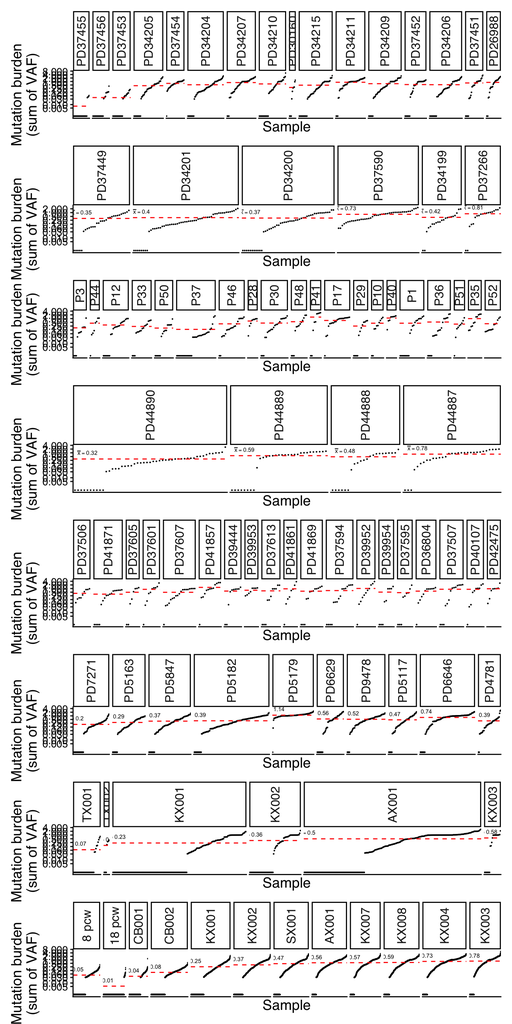

```r
wrap_plots(plot_list,ncol=1)
```

### ASSESSMENT OF MUTATION RATES ~ TISSUE

```r
# Highly clonally related samples are not 'independent' measures of mtDNA mutation burden.
# Therefore, for some analyses, may choose to drop these co-correlated readings.
# For these, randomly select one of any highly clonally related clades (those with >half of shared ancestry as assessed by ultrametric tree), and drop the rest

all_samples_to_drop<-lapply(all_mito_datasets[all_cohorts],function(dataset_mito_data) {
  lapply(names(dataset_mito_data),function(this_exp_ID) {
    mut_burden<-get_mut_burden(dataset_mito_data[[this_exp_ID]]$tree.ultra)[1]
    expanded_clade_nodes<-get_expanded_clade_nodes(tree=dataset_mito_data[[this_exp_ID]]$tree.ultra,min_samples=2,height_cut_off=mut_burden/2,min_clonal_fraction = 0)
    samples_to_drop=unlist(lapply(expanded_clade_nodes$nodes,function(node) {
      clade_samples<-getTips(tree=dataset_mito_data[[this_exp_ID]]$tree.ultra,node)
      to_drop=sample(clade_samples,size=length(clade_samples)-1) #Drop all but one samples from a clade
    }))
  })
})%>%unlist()


#Prepare the data for LMER models, excluding individuals with very few samples
all_sum_of_vaf_summary_df=lapply(all_cohorts,function(this_dataset) {

  #cat(this_dataset,sep="\n")

  ref_df_cohort<-ref_df%>%filter(Cohort==this_dataset)

  #Do a version where mean/ median are calculated using all samples (even if highly clonally related)
  min_samples_per_individual=8
  sum_of_vaf_summary<-all_sum_of_vaf_df%>%
    filter(dataset==this_dataset & !Sample%in%all_samples_to_drop)%>%
    group_by(exp_ID)%>%
    summarise(n=n(),mean=mean(sum_of_vaf,na.rm=T),median=median(sum_of_vaf,na.rm = T))%>%
    mutate(dataset=this_dataset,.before=1)%>%
    filter(n>=min_samples_per_individual)%>%
    left_join(ref_df_cohort,by=c("exp_ID"="ID"))

  return(sum_of_vaf_summary)
})%>%dplyr::bind_rows()
```

First just do LMER models by dataset. Do 3 models of increasing complexity: (1) null model - constant burden across tissues/ age (2) age term (3) age and tissue interaction terms (i.e. tissue-specific mutation accumulation rates) (4) age and tissue with full interaction (i.e. tissue-specific intercepts and accumulation)

By AIC, by far the best model is the one with only an age term, and no tissue effect.

```r
# Get models of increasing complexity
#MODEL 1: Fully null model, constant burden with age
lmer.null<-lmerTest::lmer(mean~1+(1|exp_ID),data=all_sum_of_vaf_summary_df)

#MODEL 1: lmer with only an Age term i.e. a null model for which mutation rate cannot vary between tissues
lmer1<-lmerTest::lmer(mean~Age+(1|exp_ID),data=all_sum_of_vaf_summary_df)

#MODEL 2: lmer with only the age:dataset interaction term
#This way you get the term for the blood data as well
lmer2<-lmerTest::lmer(mean~Age:dataset+(1|exp_ID),data=all_sum_of_vaf_summary_df)

#MODEL 3: lmer with full set of Age*dataset terms
lmer3<-lmerTest::lmer(mean~Age*dataset+(1|exp_ID),data=all_sum_of_vaf_summary_df)

#Compare MODELS using the AIC
AIC(lmer.null,lmer1,lmer2, lmer3)
```

```
##           df        AIC
## lmer.null  3   9.380463
## lmer1      4 -21.434731
## lmer2     11  39.001734
## lmer3     18  59.606065
```

```r
diff(AIC(lmer.null,lmer1,lmer2, lmer3)$AIC)
```

```
## [1] -30.81519  60.43647  20.60433
```

Now categorise by tissue type, not just dataset as some studies actually include the same tissues. Could this be masking the tissue effect? No, the original model with only an age term is still the best model by AIC.

```r
#Add a "tissue_cat" variable which groups together Colon samples and the haematopoietic samples
unique(all_sum_of_vaf_summary_df$Tissue_type)
```

```
##  [1] "Bronchial"
##  [2] "Colon_normal"
##  [3] "Colon_IBD"
##  [4] "Colon_MAP"
##  [5] "Endometrium"
##  [6] "MPN"
##  [7] "Lymphoid_PeripheralBlood"
##  [8] "Lymphoid_BoneMarrowPeripheralBloodSpleen"
##  [9] "Lymphoid_Tonsil"
## [10] "Foetal"
## [11] "Adult_Cord"
```

```r
all_sum_of_vaf_summary_df$tissue_cat<-ifelse(grepl("Colon",all_sum_of_vaf_summary_df$Tissue_type),"Colon",
                                             ifelse(grepl("Endometrium",all_sum_of_vaf_summary_df$Tissue_type),"Endometrium",
                                                    ifelse(grepl("Bronchial",all_sum_of_vaf_summary_df$Tissue_type),"Bronchial",
                                                           "Haematopoietic")))

#Run the regression with this as the predictor variable
lmer2.tissue_cat<-lmerTest::lmer(mean~Age:tissue_cat+(1|exp_ID),data=all_sum_of_vaf_summary_df)
lmer3.tissue_cat<-lmerTest::lmer(mean~Age*tissue_cat+(1|exp_ID),data=all_sum_of_vaf_summary_df)

AIC(lmer.null,lmer1,lmer2.tissue_cat, lmer3.tissue_cat)
```

```
##                  df        AIC
## lmer.null         3   9.380463
## lmer1             4 -21.434731
## lmer2.tissue_cat  7  -6.639651
## lmer3.tissue_cat 10   1.538011
```

```r
diff(AIC(lmer.null,lmer1,lmer2.tissue_cat, lmer3.tissue_cat)$AIC)
```

```
## [1] -30.815194  14.795080   8.177662
```

Plot the results of the model with tissue-specific age coefficients. While this wasn’t the “best model” this is still helpful to give a hint of any tissue-specific differences in accumulation rate, and how big these might be.

```r
#Plot results of the lmer with both fixed and Age interaction term
CI_table<-confint(lmer2)
```

```
## Computing profile confidence intervals ...
```

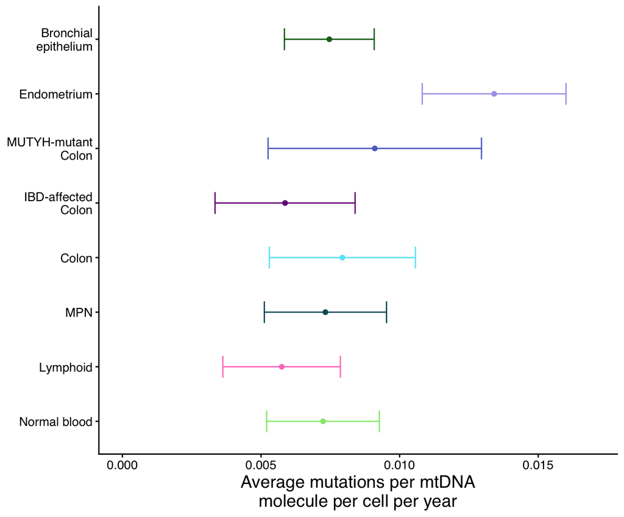

```r
lmer_info_for_plotting<-as.data.frame(summary(lmer2)$coefficients)%>%
  tibble::rownames_to_column(var="name")%>%
  left_join(as.data.frame(CI_table)%>%tibble::rownames_to_column(var="name"),by="name")%>%
  filter(grepl("dataset",name))%>%
  mutate(name=gsub("dataset","",name))%>%
  mutate(term_type=ifelse(grepl("Age",name),"Age interaction term","Fixed term"))%>%
  mutate(dataset=gsub("Age:","",name))%>%
  mutate(dataset=factor(name_conversion_vec[dataset],levels=name_conversion_vec))

p1.1<-lmer_info_for_plotting%>%
  ggplot(aes(y=dataset,x=Estimate,xmin=`2.5 %`,xmax=`97.5 %`,col=dataset))+
  geom_point()+
  scale_color_manual(values=tissue_cols)+
  geom_errorbar(width=0.4)+
  theme_classic()+
  scale_x_continuous(limits=c(0,0.017))+
  my_markdown_theme+
  theme(axis.title.y=element_blank(),legend.position = "none")+
  labs(x="Average mutations per mtDNA\nmolecule per cell per year")

p1.1
```

```r
## Tissue level plotting of lmer----

# Create prediction dataframe
pred_df <- expand.grid(
  Age = seq(min(all_sum_of_vaf_summary_df$Age),
            max(all_sum_of_vaf_summary_df$Age),
            length.out = 100),
  dataset = names(name_conversion_vec)
)

# Get predictions - re.form = NA excludes random effects
# giving population-level predictions
pred_df$fit <- predict(lmer2, newdata = pred_df, re.form = NA)

library(performance)
check_heteroscedasticity(lmer2)
# Confidence intervals via bootstrap
boot_ci <- lme4::bootMer(lmer2,
                   FUN = function(x) predict(x, newdata = pred_df, re.form = NA),
                   nsim = 1000,
                   use.u = F,
                   type = "parametric")

pred_df$lower <- apply(boot_ci$t, 2, quantile, 0.025)
pred_df$upper <- apply(boot_ci$t, 2, quantile, 0.975)

# Bootstrap the model coefficients directly
boot_coef <- lme4::bootMer(lmer2,
                     FUN = lme4::fixef,
                     nsim = 1000,
                     use.u = FALSE,
                     type = "parametric")

boot_ci <- apply(boot_coef$t, 2, quantile, c(0.025, 0.975))
t(boot_ci)
```

```
##                         2.5%       97.5%
## (Intercept)      0.014256526 0.178855464
## Age:datasetblood 0.005060691 0.009319923
## Age:datasetHL    0.005255871 0.010560168
## Age:datasetKY    0.005796534 0.009092531
## Age:datasetLM    0.010839447 0.016197100
## Age:datasetlymph 0.003565874 0.007898674
## Age:datasetNW    0.005081320 0.009384801
## Age:datasetPR    0.005088824 0.013212787
## Age:datasetSO    0.003247594 0.008295723
```

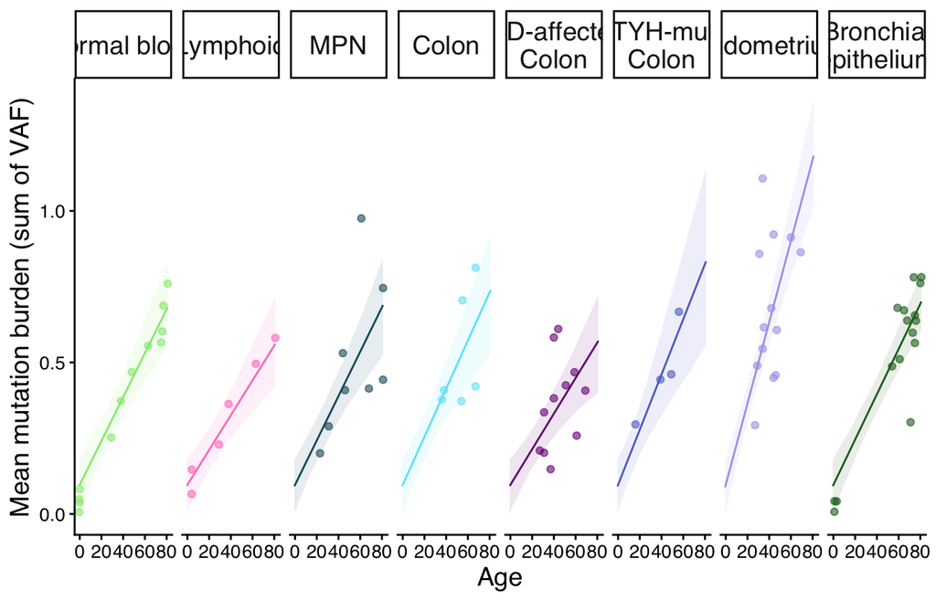

```r
mutburden_by_age_and_tissue_plot<-ggplot() +
  geom_ribbon(data = pred_df%>%mutate(dataset=factor(name_conversion_vec[dataset],name_conversion_vec)),
              aes(x = Age, ymin = lower, ymax = upper,
                  fill = dataset), alpha = 0.1) +
  geom_line(data = pred_df%>%mutate(dataset=factor(name_conversion_vec[dataset],name_conversion_vec)),
            aes(x = Age, y = fit, colour = dataset)) +
  geom_point(data = all_sum_of_vaf_summary_df%>%mutate(dataset=factor(name_conversion_vec[dataset],name_conversion_vec)),
             aes(x = Age, y = mean, colour = dataset),
             alpha = 0.6) +
  scale_colour_manual(values = tissue_cols) +
  scale_fill_manual(values = tissue_cols) +
  facet_grid(~dataset)+
  theme_classic() +
  my_markdown_theme+
  labs(y = "Mean mutation burden (sum of VAF)")+
  theme(legend.position="none")
mutburden_by_age_and_tissue_plot
```

```r
save_plot(filename = paste0(plots_dir,"mutburden_by_age_and_tissue_plot.pdf"),mutburden_by_age_and_tissue_plot,width=7,height=2)
```

## SELECTION ANALYSIS

```r
library(dndscv)
mtref_rda_path=ifelse(Sys.info()['sysname']=="Darwin",paste0(root_dir,"/data/mtref.rda"),"/lustre/scratch126/casm/team154pc/ms56/Mitochondria_study/mtref.rda")
input.dir <- paste0(root_dir,"/dnds_tables/")

dnds_theme<-theme(panel.border = element_rect(color = "black",
                                              fill = NA,
                                              linewidth = 0.75),
                  strip.text = element_text(face="plain", size=6, colour = "black",),
                  strip.background = element_rect(fill="white", colour="black", linewidth =1),
                  axis.text.x = element_text(color = "black", size = 6, angle = 0, hjust = .5, vjust = 0.5, face = "plain"),
                  axis.text.y = element_text(color = "black", size = 6, angle = 0, hjust = 1, vjust = 0, face = "plain"),
                  axis.title.x = element_text(color = "black", size = 8, angle = 0, hjust = .5, vjust = 0, face = "plain"),
                  axis.title.y = element_text(color = "black", size = 8, angle = 90, hjust = .5, vjust = .5, face = "plain",
                                              margin = margin(t = 0, r = 10, b = 0, l = 0)),
                  plot.title = element_text(color = "black", size = 10, hjust = .5, face = "plain"),
                  legend.position = "right")

#exclude ND6 from analysis since its on the other strand
all_mtDNA_genes <- c("MT-CYB", "MT-ND5", "MT-ND2", "MT-ND4", "MT-ND1", "MT-CO3", "MT-ATP6","MT-ND3", "MT-ATP8", "MT-ND4L", "MT-CO2", "MT-CO1","MT-ND5","MT-ND6")
target_genes <- c("MT-CYB", "MT-ND5", "MT-ND2", "MT-ND4", "MT-ND1", "MT-CO3", "MT-ATP6","MT-ND3", "MT-ATP8", "MT-ND4L", "MT-CO2", "MT-CO1")

#Define a gene order by which respiratory chain complex they are part of
gene_order=c(paste0("MT-ND",1:6),"MT-ND4L","MT-CYB",paste0("MT-CO",1:3),"MT-ATP6","MT-ATP8")
gene_order<-gene_order[gene_order%in%target_genes]

# Vector to rename the dnds types in more understandable format
rename_vec=c("Missense","Nonsense","Truncating","Overall")
names(rename_vec)=c("wmis","wnon","wtru","wall")

df_tidy_annotated<-Map(df_tidy=all_df_tidy,this_tissue=names(all_df_tidy),function(df_tidy,this_tissue) {

  #cat(this_tissue,sep="\n")

  # read in the mtdna variant file and remove patient id
  mtdna.variant.data <- df_tidy%>%
    separate("mut_ref", c("chr", "pos", "ref", "mut"), "_")%>%
    mutate(pos=as.numeric(pos))%>%
    dplyr::select("sampleID"=Sample,chr,pos,ref,mut,vaf)%>% # next, rename/reorder the columns to make them compatible with dnds input format
    dplyr::filter(!duplicated(.))%>% # remove duplicated variants
    arrange(sampleID,pos)

  # run dnds with the mtDNA variants to annotate them (the selection analysis isn't actually used here)
  mtdna.dndsout <- suppressMessages(dndscv(mtdna.variant.data,
                          gene_list=all_mtDNA_genes,
                          refdb = mtref_rda_path,
                          numcode = 2,
                          max_coding_muts_per_sample = Inf,
                          max_muts_per_gene_per_sample = Inf))

  # get the results with the annotated variants
  annotated.mtdna.variants <- left_join(mtdna.variant.data,mtdna.dndsout$annotmuts,by=c("sampleID","chr","pos","ref","mut"))%>%
    tidyr::replace_na(replace=list(impact="Non-Coding"))%>%
    mutate(tissue=this_tissue,.before=1)
  return(annotated.mtdna.variants)
})%>%dplyr::bind_rows()

complete.annotated.mutation.table<-df_tidy_annotated%>%
  left_join(all_df_tidy%>%dplyr::bind_rows()%>%dplyr::select(Sample,exp_ID),by=c("sampleID"="Sample"),relationship="many-to-many")%>%
  dplyr::rename("patientID"=exp_ID)%>%
  filter(!duplicated(.))%>%
  arrange(patientID,pos)%>% # order the dataframe
  tidyr::unite(col="mut_ref",chr,pos,ref,mut,sep="_",remove=F)

head(complete.annotated.mutation.table)
```

```
##   tissue      sampleID     mut_ref chr  pos ref mut        vaf gene strand
## 1  blood PD41768gs_hum   MT_58_T_C  MT   58   T   C 0.03536977 <NA>     NA
## 2  blood PD41768dc_hum  MT_198_C_T  MT  198   C   T 0.04884668 <NA>     NA
## 3  blood PD41768gl_hum  MT_198_C_T  MT  198   C   T 0.08159393 <NA>     NA
## 4  blood PD41768kj_hum  MT_198_C_T  MT  198   C   T 0.04900977 <NA>     NA
## 5  blood  PD41768v_hum  MT_198_C_T  MT  198   C   T 0.04835590 <NA>     NA
## 6  blood PD41768fc_hum MT_2655_G_A  MT 2655   G   A 0.07189542 <NA>     NA
##   ref_cod mut_cod ref3_cod mut3_cod aachange ntchange codonsub     impact  pid
## 1    <NA>    <NA>     <NA>     <NA>     <NA>     <NA>     <NA> Non-Coding <NA>
## 2    <NA>    <NA>     <NA>     <NA>     <NA>     <NA>     <NA> Non-Coding <NA>
## 3    <NA>    <NA>     <NA>     <NA>     <NA>     <NA>     <NA> Non-Coding <NA>
## 4    <NA>    <NA>     <NA>     <NA>     <NA>     <NA>     <NA> Non-Coding <NA>
## 5    <NA>    <NA>     <NA>     <NA>     <NA>     <NA>     <NA> Non-Coding <NA>
## 6    <NA>    <NA>     <NA>     <NA>     <NA>     <NA>     <NA> Non-Coding <NA>
##   patientID
## 1    18 pcw
## 2    18 pcw
## 3    18 pcw
## 4    18 pcw
## 5    18 pcw
## 6    18 pcw
```

### Compare annotation with nuclear vs mitochondrial genetic code.

Run analysis with the (incorrect) nuclear annotation for comparison. This is because in an initial version of the analysis, we used the incorrect genetic code, so want to show here how this initially altered the results, and how it compares with the correct annotation.

```r
## Compare results with those from when annotated with the nuclear genetic code ----
df_tidy_annotated_NUC<-Map(df_tidy=all_df_tidy,this_tissue=names(all_df_tidy),function(df_tidy,this_tissue) {

  #cat(this_tissue,sep="\n")

  # read in the mtdna variant file and remove patient id
  mtdna.variant.data <- df_tidy%>%
    separate("mut_ref", c("chr", "pos", "ref", "mut"), "_")%>%
    mutate(pos=as.numeric(pos))%>%
    dplyr::select("sampleID"=Sample,chr,pos,ref,mut,vaf)%>% # next, rename/reorder the columns to make them compatible with dnds input format
    dplyr::filter(!duplicated(.))%>% # remove duplicated variants
    arrange(sampleID,pos)

  # run dnds with the mtDNA variants to annotate them (the selection analysis isn't actually used here)
  mtdna.dndsout <- dndscv(mtdna.variant.data,
                          gene_list=all_mtDNA_genes,
                          refdb = mtref_rda_path,
                          numcode = 1,
                          max_coding_muts_per_sample = Inf,
                          max_muts_per_gene_per_sample = Inf)

  # get the results with the annotated variants
  annotated.mtdna.variants <- left_join(mtdna.variant.data,mtdna.dndsout$annotmuts,by=c("sampleID","chr","pos","ref","mut"))%>%
    tidyr::replace_na(replace=list(impact="Non-Coding"))%>%
    mutate(tissue=this_tissue,.before=1)
  return(annotated.mtdna.variants)
})%>%dplyr::bind_rows()

complete.annotated.mutation.table.NUC<-df_tidy_annotated_NUC%>%
  left_join(all_df_tidy%>%dplyr::bind_rows()%>%dplyr::select(Sample,exp_ID),by=c("sampleID"="Sample"),relationship="many-to-many")%>%
  dplyr::rename("patientID"=exp_ID)%>%
  filter(!duplicated(.))%>%
  arrange(patientID,pos)%>% # order the dataframe
  tidyr::unite(col="mut_ref",chr,pos,ref,mut,sep="_",remove=F)
```

Here we show how the incorrect annotation changes the numbers of mutations with different consequences (i.e. truncating vs missense vs synonymous)

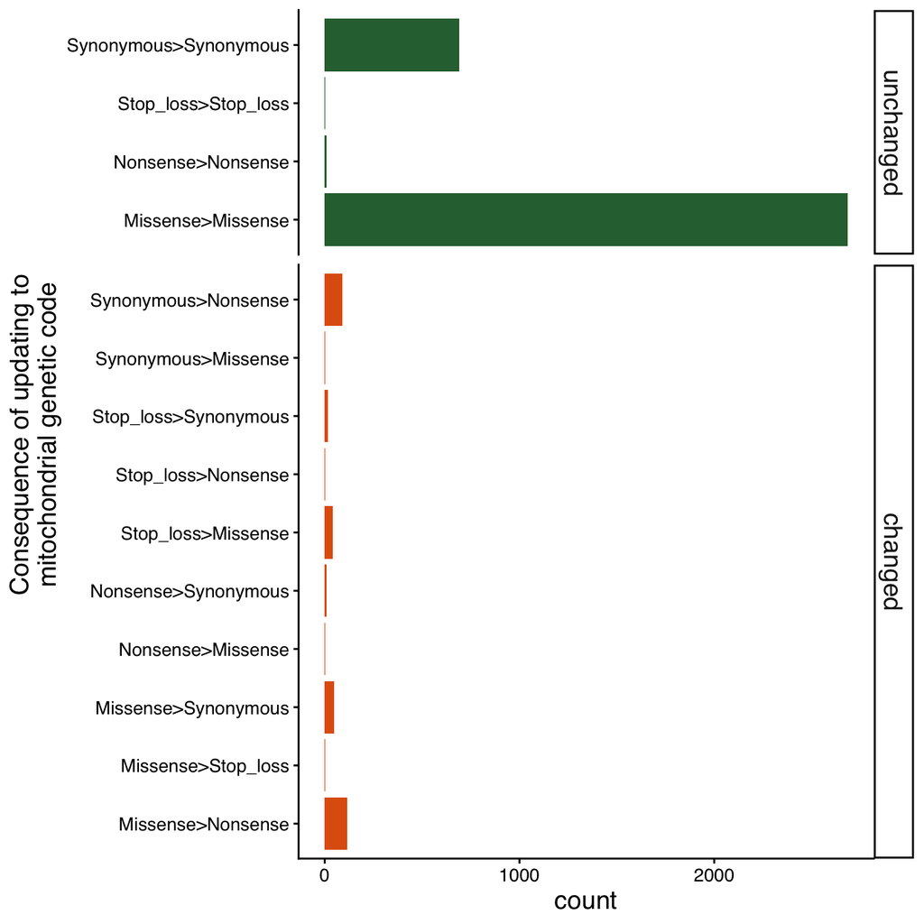

```r
impact_comparison_df<-left_join(complete.annotated.mutation.table,
          complete.annotated.mutation.table.NUC%>%dplyr::select(tissue,sampleID,mut_ref,codonsub,"impact_NUC"=impact),
          by = join_by(tissue, sampleID, mut_ref, codonsub))%>%
  dplyr::select(tissue,sampleID,mut_ref,codonsub,impact,impact_NUC)

consequence_change_plot<-impact_comparison_df%>%
  filter(tissue!="blood")%>%
  mutate(change=paste(impact_NUC,impact,sep=">"))%>%
  mutate(altered=ifelse(impact_NUC==impact,"unchanged","changed"))%>%
  filter(impact!="Non-Coding")%>%
  mutate(altered=factor(altered,levels=c("unchanged","changed")))%>%
  ggplot(aes(y=change,fill=altered))+
  geom_bar()+
  facet_grid(rows=vars(altered),scales="free",space="free_y")+
  theme_classic()+
  scale_fill_manual(values=rev(c("#e06010","#2d6e3e")),guide="none")+
  my_markdown_theme+
  labs(y="Consequence of updating to\nmitochondrial genetic code")
consequence_change_plot
```

```r
save_plot(filename = paste0(plots_dir,"consequence_change_plot_CROSSTISSUE.pdf"),consequence_change_plot,width=3.5,height=2.5)
```

```r
impact_comparison_df%>%
  filter(impact!="Non-Coding" & tissue!="blood")%>%
  mutate(change=paste(impact_NUC,impact,sep=">"))%>%
  mutate(altered=ifelse(impact_NUC==impact,"unchanged","changed"))%>%
  pull(altered)%>%table()
```

```
## .
##   changed unchanged
##       329      3389
```

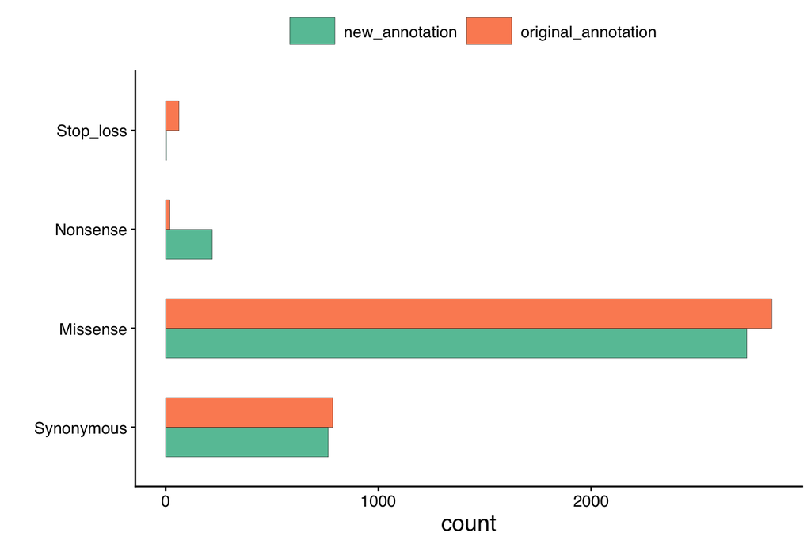

```r
total_numbers_old_vs_new_plot<-impact_comparison_df%>%
  filter(tissue!="blood")%>%
  dplyr::select(mut_ref,"new_annotation"=impact,"original_annotation"=impact_NUC)%>%
  tidyr::gather(-mut_ref,key="annotation",value="impact")%>%
  filter(impact!="Non-Coding")%>%
  mutate(impact=factor(impact,levels=c("Synonymous","Missense","Nonsense","Stop_loss")))%>%
  ggplot(aes(y = impact,fill=annotation))+
  geom_bar(position="dodge",width=0.6,col="black",linewidth=0.1)+
  scale_fill_brewer(palette="Set2")+
  theme_classic()+
  my_markdown_theme+
  labs(fill="",y="")+
  theme(legend.position="top")
total_numbers_old_vs_new_plot
```

```r
save_plot(filename = paste0(plots_dir,"total_numbers_old_vs_new_plot_CROSSTISSUE.pdf"),total_numbers_old_vs_new_plot,width=3,height=2.5)
```

```r
impact_comparison_df%>%
  filter(tissue!="blood")%>%
  dplyr::select(mut_ref,"new_annotation"=impact,"original_annotation"=impact_NUC)%>%
  tidyr::gather(-mut_ref,key="annotation",value="impact")%>%
  filter(impact!="Non-Coding")%>%
  dplyr::group_by(annotation,impact)%>%
  dplyr::summarise(n=n())
```

```
## # A tibble: 8 × 3
## # Groups:   annotation [2]
##   annotation          impact         n
##   <chr>               <chr>      <int>
## 1 new_annotation      Missense    2731
## 2 new_annotation      Nonsense     219
## 3 new_annotation      Stop_loss      4
## 4 new_annotation      Synonymous   764
## 5 original_annotation Missense    2849
## 6 original_annotation Nonsense      20
## 7 original_annotation Stop_loss     63
## 8 original_annotation Synonymous   786
```

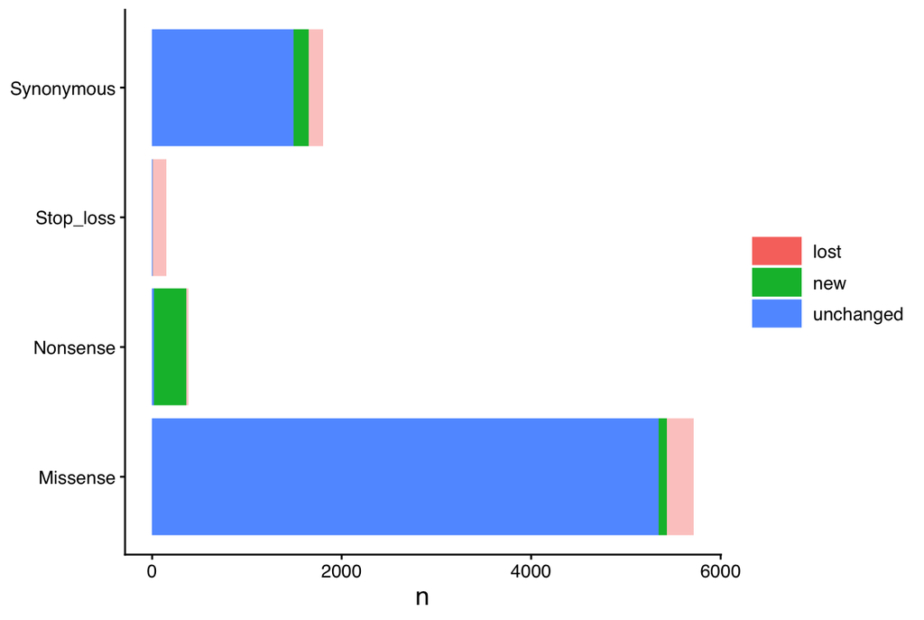

```r
simple_impact_comparison_df<-impact_comparison_df%>%
  mutate(change=paste(impact_NUC,impact,sep=">"))%>%
  mutate(altered=ifelse(impact_NUC==impact,"unchanged","changed"))

new_muts<-simple_impact_comparison_df%>%
  filter(altered=="changed")%>%
  group_by(impact)%>%
  dplyr::summarise(new=n())

lost_muts<-simple_impact_comparison_df%>%
  filter(altered=="changed")%>%
  group_by(impact_NUC)%>%
  dplyr::summarise(lost=n())%>%dplyr::rename("impact"=impact_NUC)

simple_impact_comparison_df%>%
  filter(altered=="unchanged" & impact!="Non-Coding")%>%
  group_by(impact)%>%
  dplyr::summarise(unchanged=n())%>%
  left_join(new_muts,by="impact")%>%left_join(lost_muts,by="impact")%>%
  tidyr::gather(-impact,key="result",value="n")%>%
  ggplot(aes(y=impact,x=n,fill=result,alpha = result!="lost"))+
  geom_bar(stat="identity")+
  scale_alpha(range=c(0.4,1),guide="none")+
  theme_classic()+
  my_markdown_theme+
  theme(axis.title.y=element_blank(),legend.title = element_blank())
```

### Summarise coding mutation consequences

First summarise the coding mutation consequences per gene. This is looking across all the comparator datasets (see we exclude only the original “blood” mutations that we analysed separately).

```r
mutation_type_by_gene<-complete.annotated.mutation.table%>%
  filter(impact!="Non-Coding" & tissue!="blood")%>%
  distinct(sampleID,mut_ref,gene,impact)%>%
  group_by(gene,impact)%>%
  dplyr::summarise(n=n())%>%
  ggplot(aes(y=gene,x=n,fill=impact))+
  geom_bar(position="stack",stat="identity",col="black",linewidth=0.1)+
  scale_fill_manual(values=mut_type_cols)+
  scale_x_continuous(breaks=seq(0,1400,200))+
  theme_classic()+
  my_markdown_theme+
  theme(axis.title.y=element_blank(),
        axis.text.y=element_text(face="italic"))+
  labs(x="Number of variants",fill="Mutation\nconsequence")
```

```
## `summarise()` has regrouped the output.
## ℹ Summaries were computed grouped by gene and impact.
## ℹ Output is grouped by gene.
## ℹ Use `summarise(.groups = "drop_last")` to silence this message.
## ℹ Use `summarise(.by = c(gene, impact))` for per-operation grouping
##   (`?dplyr::dplyr_by`) instead.
```

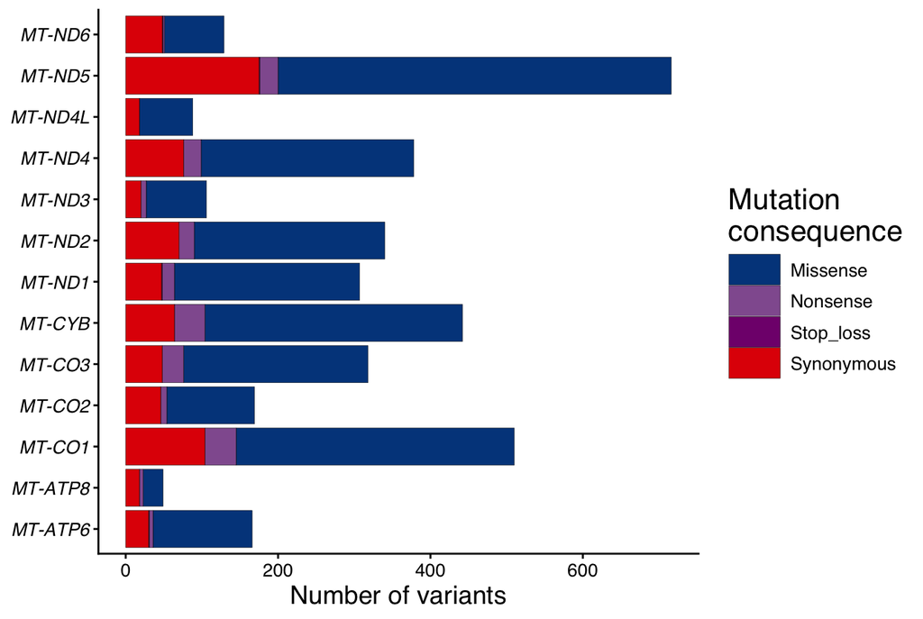

```r
mutation_type_by_gene
```

```r
save_plot(filename = paste0(plots_dir,"mutation_type_by_gene_CROSSTISSUE.pdf"),mutation_type_by_gene,width=3.5,height=2.5)
```

Now summarise the coding mutation consequences per tissue (across genes).

```r
mutation_type_by_tissue<-complete.annotated.mutation.table%>%
  filter(impact!="Non-Coding" & !tissue%in%c("blood","CML"))%>%
  distinct(tissue,sampleID,mut_ref,gene,impact)%>%
  group_by(tissue,impact)%>%
  dplyr::summarise(n=n())%>%
  dplyr::mutate(tissue=factor(name_conversion_vec[tissue],levels=name_conversion_vec))%>%
  ggplot(aes(y=tissue,x=n,fill=impact))+
  geom_bar(position="stack",stat="identity",col="black",linewidth=0.1)+
  scale_fill_manual(values=mut_type_cols)+
  scale_x_continuous(breaks=seq(0,1400,200))+
  theme_classic()+
  my_markdown_theme+
  theme(axis.title.y=element_blank(),
        axis.text.y=element_text(face="italic"))+
  labs(x="Number of coding variants",fill="Mutation\nconsequence")
```

```
## `summarise()` has regrouped the output.
## ℹ Summaries were computed grouped by tissue and impact.
## ℹ Output is grouped by tissue.
## ℹ Use `summarise(.groups = "drop_last")` to silence this message.
## ℹ Use `summarise(.by = c(tissue, impact))` for per-operation grouping
##   (`?dplyr::dplyr_by`) instead.
```

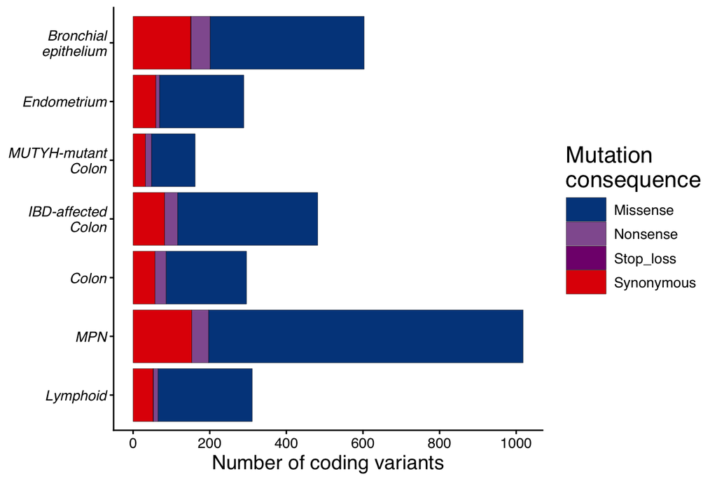

```r
mutation_type_by_tissue
```

```r
save_plot(filename = paste0(plots_dir,"mutation_type_by_tissue_CROSSTISSUE.pdf"),mutation_type_by_tissue,width=3.5,height=2)
```

### Combine epithelial tissues

Given the different cellular dynamics of epithelial tissues, it seems plausible that mitochondrial dynamics and selection may be different across epithelial tissues. Therefore, to increase power to detect this, combine results across colon, bronchial epithlium and endometrium.

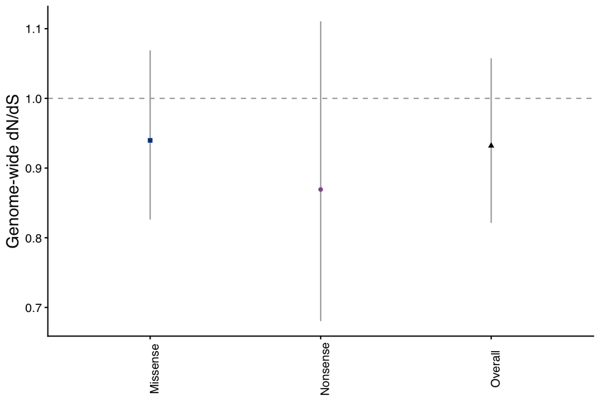

```r
epithelial_datasets=c("HL","KY","LM","PR","SO")
combined_epithelial_for_dnds<-complete.annotated.mutation.table%>%
  dplyr::filter(tissue%in%epithelial_datasets)%>%
  separate("mut_ref", c("chr", "pos", "ref", "mut"), "_")%>%
  mutate(pos=as.numeric(pos))%>%
  dplyr::distinct(sampleID,chr,pos,ref,mut,.keep_all = F)%>%
  arrange(sampleID,pos)


mtdna.dndsout.combined.epithelial <- dndscv(combined_epithelial_for_dnds,
                        gene_list=target_genes,
                        refdb = mtref_rda_path,
                        numcode=2,
                        max_coding_muts_per_sample = Inf,
                        max_muts_per_gene_per_sample = Inf)

mtdna.dndsout.combined.epithelial$globaldnds%>%
  filter(!is.na(name) & complete.cases(.))%>%
  mutate(name=rename_vec[name])%>%
  filter(name%in%c("Overall","Nonsense","Missense"))%>%
  ggplot(aes(x=name,y = mle, ymin = cilow, ymax = cihigh, color = name, shape = name)) +
  geom_linerange(position= position_dodge2(width=0.75), linewidth = 0.5, color="darkgrey") +
  geom_point(position=position_dodge2(width=0.75), size = 1.5) +
  labs(y = "Genome-wide dN/dS", x = "Tissue") +
  theme_classic() +
  scale_color_manual(values = mut_type_cols, name="Mutation type") +
  scale_shape_manual(values = c(15, 16, 17, 18), name = "Mutation type") +
  geom_hline(yintercept=1, linetype='dashed', col = 'darkgrey', linewidth = 0.5) +
  my_markdown_theme+
  theme(axis.title.x=element_blank(),
        axis.text.x = element_text(angle=90),
        legend.position="none")
```

```r
#Gives some sense of differing heteroplasmy distributions
#But bear in mind there are multiple non-independent measures for some variants
#Would need to account for this e.g. by taking single measure of e.g. max VAF of variant per individual
syn_vals <- complete.annotated.mutation.table %>%
  dplyr::filter(tissue%in%epithelial_datasets)%>%
  dplyr::filter(impact == "Synonymous"&vaf>0.01) %>% pull(vaf)

mis_vals <- complete.annotated.mutation.table %>%
  dplyr::filter(tissue%in%epithelial_datasets)%>%
  dplyr::filter(impact == "Missense"&vaf>0.01) %>% pull(vaf)

nons_vals <- complete.annotated.mutation.table %>%
  dplyr::filter(tissue%in%epithelial_datasets)%>%
  dplyr::filter(impact == "Nonsense"&vaf>0.01) %>% pull(vaf)

ks_syn_mis <- ks.test(syn_vals, mis_vals)
ks_syn_non <- ks.test(syn_vals, nons_vals)

find_ks_coords <- function(vals1, vals2) {
  ecdf1 <- ecdf(vals1)
  ecdf2 <- ecdf(vals2)
  all_y <- sort(c(vals1, vals2))
  diffs <- abs(ecdf1(all_y) - ecdf2(all_y))
  max_y <- all_y[which.max(diffs)]
  data.frame(
    y    = max_y,
    xmin = min(ecdf1(max_y), ecdf2(max_y)),
    xmax = max(ecdf1(max_y), ecdf2(max_y))
  )
}

sapply(list(syn_vals,mis_vals,nons_vals),length)
```

```
## [1]  380 1312  139
```

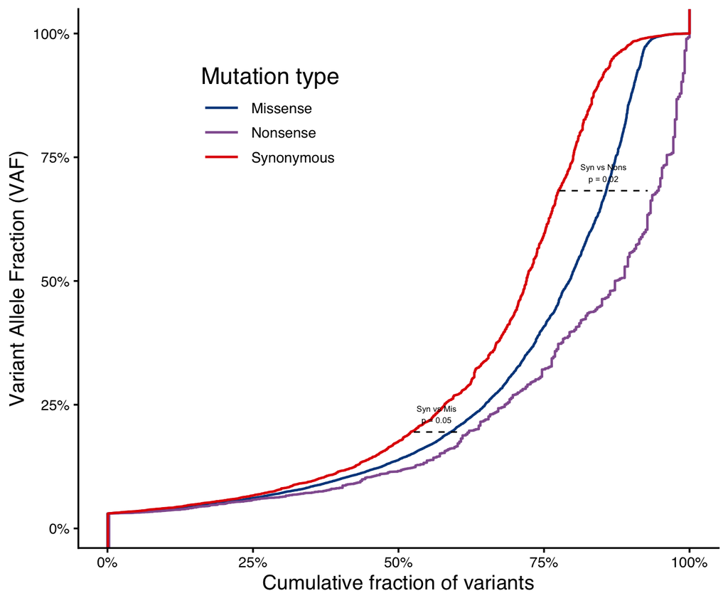

```r
fmt_p <- function(p) {
  ifelse(p < 0.001, "p < 0.001",
         ifelse(p < 0.01,  paste0("p = ", round(p, 3)),
                paste0("p = ", round(p, 2))))
}

coords_non <- find_ks_coords(syn_vals, nons_vals)
coords_mis <- find_ks_coords(syn_vals, mis_vals)


mutation_type_ecdf_plot<-complete.annotated.mutation.table %>%
  filter(impact != "Non-Coding" & impact != "Stop_loss") %>%
  ggplot(aes(y = vaf, col = impact)) +
  stat_ecdf(geom = "step", linewidth = 0.8) +
  # Syn vs Missense segment
  annotate("segment",
           x = coords_mis$xmin, xend = coords_mis$xmax,
           y = coords_mis$y,    yend = coords_mis$y,
           colour = "black", linewidth = 0.5, linetype = "dashed") +
  annotate("text",
           x = mean(c(coords_mis$xmin, coords_mis$xmax)),
           y = coords_mis$y,
           vjust = -0.5, size = 2,
           label = paste0("Syn vs Mis\n", fmt_p(ks_syn_mis$p.value))) +
  # Syn vs Nonsense segment
  annotate("segment",
           x = coords_non$xmin, xend = coords_non$xmax,
           y = coords_non$y,    yend = coords_non$y,
           colour = "black", linewidth = 0.5, linetype = "dashed") +
  annotate("text",
           x = mean(c(coords_non$xmin, coords_non$xmax)),
           y = coords_non$y,
           vjust = -0.5, size = 2,
           label = paste0("Syn vs Nons\n", fmt_p(ks_syn_non$p.value)))+
  scale_y_continuous(limits = c(0.01, 1),
                     labels = scales::percent_format(accuracy = 1),
                     name = "Variant Allele Fraction (VAF)") +
  scale_x_continuous(labels = scales::percent_format(accuracy = 1),
                     name = "Cumulative fraction of variants") +
  theme_classic(base_size = 13) +
  scale_color_manual(values = mut_type_cols) +
  my_markdown_theme +
  theme(panel.grid.minor = element_blank(),
        legend.position = c(0.3, 0.8)) +
  labs(col = "Mutation type")
mutation_type_ecdf_plot
```

```r
save_plot(filename = paste0(plots_dir,"mutation_type_ecdf_plot_EPITHELIAL.pdf"),mutation_type_ecdf_plot,width=2.5,height=2)
```

Now, SPLIT THE EPITHELIAL TISSUE analysis at the dichotomous vaf threshold from blood (20%)

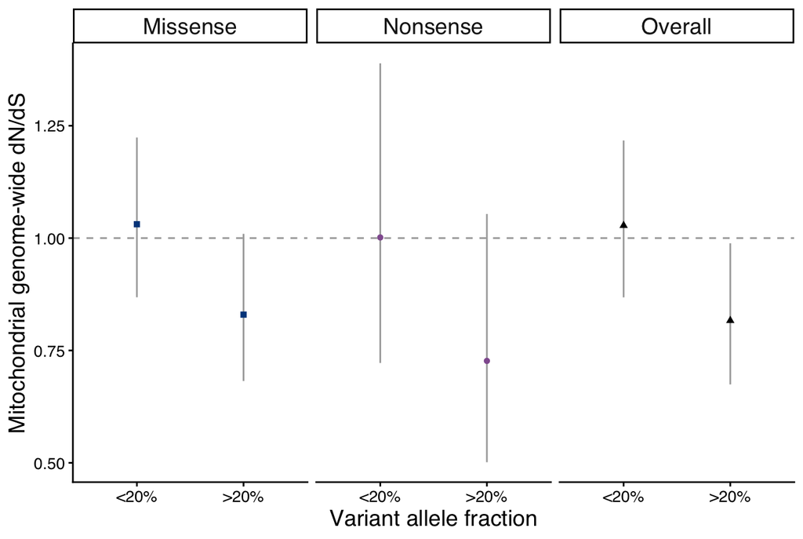

```r
cutoffs=list(low_vaf=c(0.03,0.2),
             high_vaf=c(0.2,1.1))
cutoff_names=c("<20%",">20%")

# cutoffs=list(vaf1=c(0.03,0.1),
#              vaf2=c(0.1,0.2),
#              vaf3=c(0.2,0.5),
#              vaf4=c(0.5,1.011))
# cutoff_names=c("<10%","10-20%","20-50%",">50%")


dndsout.epithelial<-lapply(cutoffs,function(cutoffs) {
  combined_nonblood_for_dnds<-complete.annotated.mutation.table%>%
    dplyr::filter(tissue%in%epithelial_datasets & vaf>=cutoffs[1] & vaf<cutoffs[2])%>%
    separate("mut_ref", c("chr", "pos", "ref", "mut"), "_")%>%
    mutate(pos=as.numeric(pos))%>%
    dplyr::select(sampleID,chr,pos,ref,mut)%>%
    dplyr::filter(!duplicated(.))%>%
    arrange(sampleID,pos)

  mtdna.dndsout.combined.epithelial <- dndscv(combined_nonblood_for_dnds,
                                            gene_list=target_genes,
                                            refdb = mtref_rda_path,
                                            numcode=2,
                                            max_coding_muts_per_sample = Inf,
                                            max_muts_per_gene_per_sample = Inf)
  return(mtdna.dndsout.combined.epithelial)
})

globaldnds_by_vaf_epithelial<-Map(dndsout=dndsout.epithelial,vaf_group=cutoff_names,function(dndsout,vaf_group) {
  dndsout$globaldnds%>%
    filter(!is.na(name) & complete.cases(.))%>%
    mutate(name=rename_vec[name])%>%
    mutate(VAF=vaf_group)
})%>%dplyr::bind_rows()

dnds_global_by_dichotomous_vaf_epithelial_plot<-globaldnds_by_vaf_epithelial%>%
  filter(!is.na(name) & complete.cases(.))%>%
  filter(name%in%c("Overall","Nonsense","Missense"))%>%
  mutate(VAF=factor(VAF,levels = cutoff_names))%>%
  ggplot(aes(x=VAF,y = mle, ymin = cilow, ymax = cihigh, color = name, shape = name)) +
  geom_linerange(position= position_dodge2(width=0.75), linewidth = 0.5, color="darkgrey") +
  geom_point(position=position_dodge2(width=0.75), size = 1.5) +
  labs(y = "Mitochondrial genome-wide dN/dS", x = "Variant allele fraction") +
  theme_classic() +
  facet_grid(~name)+
  scale_color_manual(values = mut_type_cols, name="Mutation type") +
  scale_shape_manual(values = c(15, 16, 17, 18), name = "Mutation type") +
  geom_hline(yintercept=1, linetype='dashed', col = 'darkgrey', linewidth = 0.5) +
  my_markdown_theme+
  theme(axis.text.x = element_text(angle=0),
        legend.position="none")
dnds_global_by_dichotomous_vaf_epithelial_plot
```

```r
save_plot(filename = paste0(plots_dir,"dnds_global_by_dichotomous_vaf_epithelial_plot.pdf"),dnds_global_by_dichotomous_vaf_epithelial_plot,width=3,height=2)
```

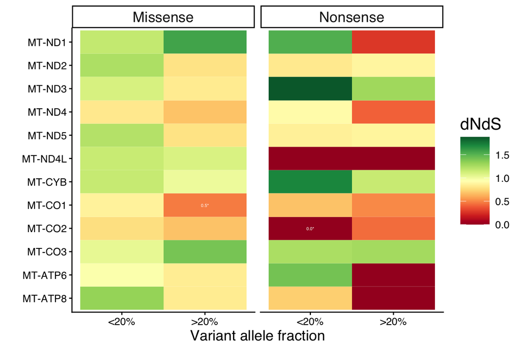

```r
selcv_res_by_tissue_and_vaf<-Map(dndsout=dndsout.epithelial,VAF_bin=c("<20%",">20%"),function(dndsout,VAF_bin) {
    temp<-dndsout$sel_cv%>%
      dplyr::select(gene_name,wmis_cv,wnon_cv,qmis_cv,qtrunc_cv)

    dplyr::bind_rows(temp%>%dplyr::select(gene_name,"dNdS"=wmis_cv,"qval"=qmis_cv)%>%mutate(type="Missense"),
                     temp%>%dplyr::select(gene_name,"dNdS"=wnon_cv,"qval"=qtrunc_cv)%>%mutate(type="Nonsense"))%>%
      mutate(VAF_group=VAF_bin)
  })%>%dplyr::bind_rows()%>%
    mutate(VAF_group=factor(VAF_group,levels=c("<20%",">20%")))

qval_cutoff=0.05
dnds_heatmap_epithelial_and_vaf_by_gene<-selcv_res_by_tissue_and_vaf%>%
  mutate(dnds_if_signif=ifelse(qval<qval_cutoff,paste0(sprintf(dNdS, fmt = '%#.1f'),"*"),""),
         dNdS=ifelse(dNdS>2,2,dNdS),
         gene_name=factor(gene_name,levels=rev(gene_order)))%>%
  ggplot(aes(y=gene_name,x=VAF_group,fill=dNdS,label=dnds_if_signif))+
  geom_tile()+
  facet_grid(~type)+
  geom_text(col="white",size=1.5)+
  theme_classic()+
  my_markdown_theme+
  theme(axis.text.x=element_text(angle=0))+
  scale_fill_gradientn(colors=RColorBrewer::brewer.pal(n=11,name = "RdYlGn"))+
  labs(x="Variant allele fraction",y="")
dnds_heatmap_epithelial_and_vaf_by_gene
```

```r
save_plot(filename = paste0(plots_dir,"dnds_heatmap_epithelial_and_vaf_by_gene.pdf"),dnds_heatmap_epithelial_and_vaf_by_gene,width=2.5,height=2)
```

### Generate global dnds by each individual tissue dataset

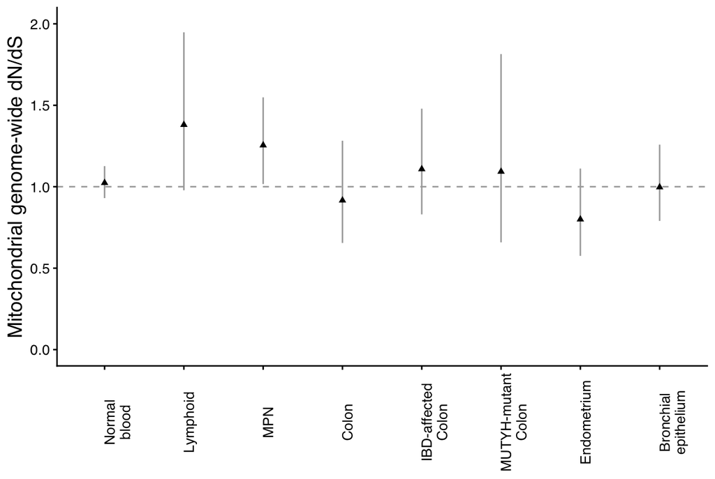

```r
dndscv_by_tissue<-Map(df_tidy=all_df_tidy[all_cohorts],this_tissue=all_cohorts,function(df_tidy,this_tissue) {

  #cat(this_tissue,sep="\n")
  tissue_info<-df_tidy%>%
    separate("mut_ref", c("chr", "pos", "ref", "mut"), "_")%>%
    mutate(pos=as.numeric(pos))%>%
    dplyr::select("sampleID"=exp_ID,chr,pos,ref,mut)%>%
    dplyr::filter(!duplicated(.))%>%
    arrange(sampleID,pos)

  mtdna.dndsout <- dndscv(tissue_info,
                          gene_list=target_genes,
                          refdb = mtref_rda_path,
                          numcode=2,
                          max_coding_muts_per_sample = Inf,
                          max_muts_per_gene_per_sample = Inf)
  return(mtdna.dndsout)
})

globaldnds_res<-Map(dndsout=dndscv_by_tissue,this_tissue=all_cohorts,function(dndsout,this_tissue) {
  dndsout$globaldnds%>%
    filter(!is.na(name) & complete.cases(.))%>%
    mutate(name=rename_vec[name])%>%
    mutate(tissue=this_tissue)
})%>%dplyr::bind_rows()

nb.cols <- length(name_conversion_vec)
mycolors <- colorRampPalette(ggsci::pal_lancet(palette = "lanonc")(9))(nb.cols)

max_dnds_value<-2
stats_to_include=c("Overall")
global_dnds_nonblood<-globaldnds_res%>%
  filter(name%in%stats_to_include)%>%
  mutate(cihigh=ifelse(cihigh>max_dnds_value,max_dnds_value,cihigh),
         tissue=factor(name_conversion_vec[tissue],levels=name_conversion_vec))%>%
  ggplot(aes(x=tissue, y = mle, ymin = cilow, ymax = cihigh, color = name, shape = name)) +
  geom_linerange(position= position_dodge2(width=0.75), linewidth = 0.5, color="darkgrey") +
  geom_point(position=position_dodge2(width=0.75), size = 1.5) +
  labs(y = "Mitochondrial genome-wide dN/dS") +
  theme_classic() +
  scale_x_discrete(labels = function(x) str_wrap(x, width = 6))+
  scale_y_continuous(limits=c(0,max_dnds_value))+
  scale_color_manual(values = mut_type_cols, name="Mutation type") +
  scale_shape_manual(values = 17, name = "Mutation type") +
  geom_hline(yintercept=1, linetype='dashed', col = 'darkgrey', linewidth = 0.5) +
  my_markdown_theme+
  theme(axis.title.x=element_blank(),
        axis.text.x = element_text(angle=90),
        legend.position="none")

global_dnds_nonblood
```

```r
save_plot(filename = paste0(plots_dir,"global_dnds_CROSSTISSUE.pdf"),global_dnds_nonblood,width=2,height=2)
```

### Get gene-level dNdS info by tissue

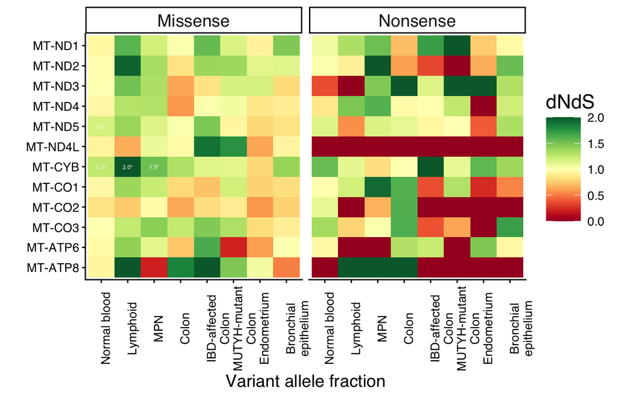

```r
qval_cutoff=0.05
selcv_res_by_tissue<-Map(dndsout=dndscv_by_tissue,this_tissue=all_cohorts,function(dndsout,this_tissue) {
  temp<-dndsout$sel_cv%>%
    dplyr::select(gene_name,wmis_cv,wnon_cv,qmis_cv,qtrunc_cv)

  dplyr::bind_rows(temp%>%dplyr::select(gene_name,"dNdS"=wmis_cv,"qval"=qmis_cv)%>%mutate(type="Missense"),
                   temp%>%dplyr::select(gene_name,"dNdS"=wnon_cv,"qval"=qtrunc_cv)%>%mutate(type="Nonsense"))%>%
    mutate(tissue=this_tissue)
})%>%dplyr::bind_rows()


dnds_heatmap_by_gene_by_tissue<-selcv_res_by_tissue%>%
  mutate(dnds_if_signif=ifelse(qval<qval_cutoff,paste0(sprintf(dNdS, fmt = '%#.1f'),"*"),""),
         dNdS=ifelse(dNdS>2,2,dNdS),
         gene_name=factor(gene_name,levels=rev(gene_order)),
         tissue=factor(name_conversion_vec[tissue],levels=name_conversion_vec))%>%
  ggplot(aes(y=gene_name,x=tissue,fill=dNdS,label=dnds_if_signif))+
  geom_tile()+
  facet_grid(~type)+
  geom_text(col="white",size=1.6)+
  theme_classic()+
  my_markdown_theme+
  theme(axis.text.x=element_text(angle=90))+
  scale_fill_gradientn(colors=RColorBrewer::brewer.pal(n=11,name = "RdYlGn"))+
  labs(x="Variant allele fraction",y="")

dnds_heatmap_by_gene_by_tissue
```

```r
save_plot(filename = paste0(plots_dir,"dnds_heatmap_by_gene_by_tissue.pdf"),dnds_heatmap_by_gene_by_tissue,width=4,height=2.5)
```

### Selection split by heteroplasmy

Enhance the tidy dataframe with ‘VAF bin’ info

```r
#Define the VAF 'bins' that will be used for comparing VAF distributions
#Can set this on a log scale, or as decile bins, or dichotomous (>/< 20%)
#Only mutations >3% are actually included
boundaries<-c(0,0.03,0.1,0.2,0.5,1)
new_VAF_groups=paste0(round(100*head(boundaries,-1)),"-",round(100*tail(boundaries,-1)),"%")
VAF_groups=data.frame(labels=new_VAF_groups,LL=head(boundaries,-1),UL=tail(boundaries,-1))

#Assign each observed VAF into its 'VAF group' bin
all_df_tidy<-lapply(all_df_tidy,function(df_tidy) {
  df_tidy$VAF_group=sapply(df_tidy$vaf,function(vaf) {
    if(vaf==0) {
      return("Absent")
    } else {
      return(VAF_groups$labels[VAF_groups$LL<vaf & VAF_groups$UL>=vaf])
    }
  })
  return(df_tidy)
})
```

Run global dNdS by VAF group

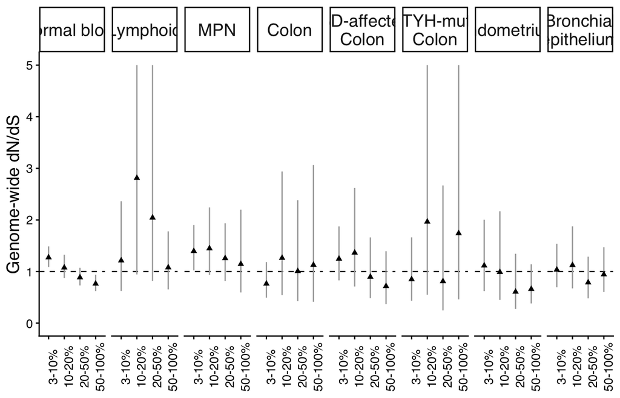

```r
dndscv_by_tissue_and_vaf<-Map(df_tidy=all_df_tidy[all_cohorts],this_tissue=all_cohorts,function(df_tidy,this_tissue) {
  #cat(this_tissue,sep = "\n")
  dndscv_by_vaf_tissue<-lapply(new_VAF_groups[2:length(new_VAF_groups)],function(VAF_bin) {
    #cat(VAF_bin,sep="\n")
    tissue_vaf_info<-df_tidy%>%
      dplyr::filter(VAF_group==VAF_bin)%>%
      separate("mut_ref", c("chr", "pos", "ref", "mut"), "_")%>%
      mutate(pos=as.numeric(pos))%>%
      dplyr::select("sampleID"=exp_ID,chr,pos,ref,mut)%>%
      dplyr::filter(!duplicated(.))%>% #only count each mutation once per individual in each VAF group
      arrange(sampleID,pos)

    mtdna.dndsout <- dndscv(tissue_vaf_info,
                            gene_list=target_genes,
                            refdb = mtref_rda_path,
                            numcode = 2,
                            max_coding_muts_per_sample = Inf,
                            max_muts_per_gene_per_sample = Inf)
    return(mtdna.dndsout)
  })
  return(dndscv_by_vaf_tissue)
})

globaldnds_res_by_tissue_and_vaf<-Map(list1=dndscv_by_tissue_and_vaf,this_tissue=all_cohorts,function(list1,this_tissue) {
  globaldnds_res_by_vaf<-Map(dndsout=list1,VAF_bin=new_VAF_groups[2:length(new_VAF_groups)],function(dndsout,VAF_bin) {
    dndsout$globaldnds%>%
      filter(!is.na(name) & complete.cases(.))%>%
      mutate(name=rename_vec[name])%>%
      mutate(VAF_group=VAF_bin)
  })%>%dplyr::bind_rows()%>%
    mutate(tissue=this_tissue)
})%>%dplyr::bind_rows()

nb.cols <- length(name_conversion_vec)
mycolors <- colorRampPalette(ggsci::pal_lancet(palette = "lanonc")(9))(3)
#mycolors<-ggsci::pal_lancet(palette = "lanonc")(9)

max_dnds_value<-5
stats_to_include=c("Overall")
global_dnds_by_tissue_and_vaf_plot<-globaldnds_res_by_tissue_and_vaf%>%
  filter(VAF_group%in%VAF_groups$labels[-1] & name%in%stats_to_include)%>%
  mutate(cihigh=ifelse(cihigh>max_dnds_value,max_dnds_value,cihigh),
         VAF_group=factor(VAF_group,levels=VAF_groups$labels[-1]),
         tissue=factor(name_conversion_vec[tissue],levels=name_conversion_vec))%>%
  ggplot(aes(x=VAF_group, y = mle, ymin = cilow, ymax = cihigh, color = name, shape = name)) +
  geom_hline(yintercept=1, linetype='dashed', col = 'black', linewidth = 0.5) +
  geom_linerange(position= position_dodge2(width=0.75), linewidth = 0.5, color="darkgrey") +
  geom_point(position=position_dodge2(width=0.75), size = 1.5) +
  labs(y = "Genome-wide dN/dS", x = "Variant allele fraction") +
  theme_classic() +
  ylim(c(0,max_dnds_value))+
  scale_color_manual(values = mut_type_cols, name="Mutation type") +
  scale_shape_manual(values = 17, name = "Mutation type") +
  theme_classic()+
  my_markdown_theme+
  facet_grid(cols=vars(tissue))+
  theme(legend.position="none",
        axis.text.x=element_text(angle=90),
        axis.title.x=element_blank(),
        strip.text.y = element_text(angle = 0))
global_dnds_by_tissue_and_vaf_plot
```

```r
save_plot(filename = paste0(plots_dir,"global_dnds_by_tissue_and_vaf_plot_CROSSTISSUE.pdf"),global_dnds_by_tissue_and_vaf_plot,width=7,height=2)
```

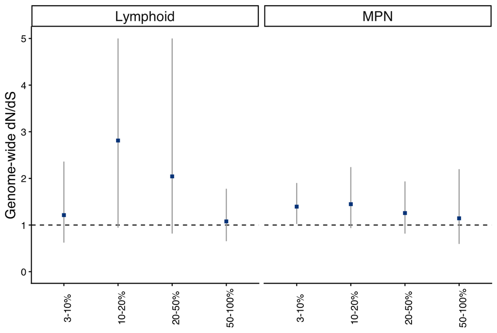

```r
max_dnds_value<-5
global_dnds_by_vaf_MPN_and_lymph_onlyplot<-globaldnds_res_by_tissue_and_vaf%>%
  filter(VAF_group%in%VAF_groups$labels[-1] & name%in%stats_to_include)%>%
  mutate(cihigh=ifelse(cihigh>max_dnds_value,max_dnds_value,cihigh),
         VAF_group=factor(VAF_group,levels=VAF_groups$labels[-1]),
         tissue=factor(name_conversion_vec[tissue],levels=name_conversion_vec))%>%
  filter(tissue%in%c("Lymphoid","MPN"))%>%
  ggplot(aes(x=VAF_group, y = mle, ymin = cilow, ymax = cihigh, color = name, shape = name)) +
  geom_hline(yintercept=1, linetype='dashed', col = 'black', linewidth = 0.5) +
  geom_linerange(position= position_dodge2(width=0.75), linewidth = 0.5, color="darkgrey") +
  geom_point(position=position_dodge2(width=0.75), size = 1.5) +
  labs(y = "Genome-wide dN/dS", x = "Variant allele fraction") +
  theme_classic() +
  ylim(c(0,max_dnds_value))+
  scale_color_manual(values = mycolors[1:2], name="Mutation type") +
  scale_shape_manual(values = c(15, 16, 17, 18), name = "Mutation type") +
  theme_classic()+
  my_markdown_theme+
  facet_grid(cols=vars(tissue))+
  theme(legend.position="none",
        axis.text.x=element_text(angle=90),
        axis.title.x=element_blank(),
        strip.text.y = element_text(angle = 0))
global_dnds_by_vaf_MPN_and_lymph_onlyplot
```

```r
save_plot(filename = paste0(plots_dir,"global_dnds_by_vaf_MPN_and_lymph_onlyplot.pdf"),global_dnds_by_vaf_MPN_and_lymph_onlyplot,width=2,height=2)
```

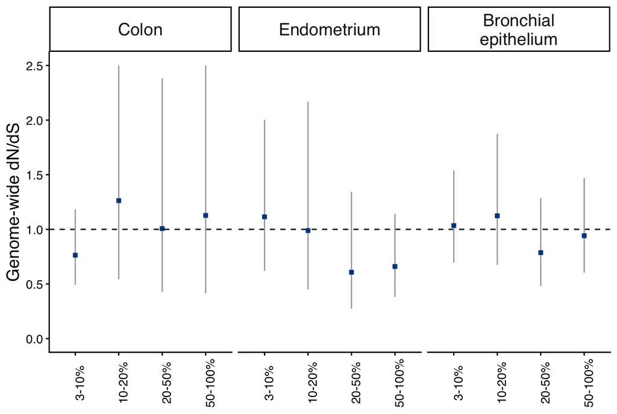

```r
max_dnds_value<-2.5
global_dnds_by_vaf_normal_nonblood_onlyplot<-globaldnds_res_by_tissue_and_vaf%>%
  filter(VAF_group%in%VAF_groups$labels[-1] & name%in%stats_to_include)%>%
  mutate(cihigh=ifelse(cihigh>max_dnds_value,max_dnds_value,cihigh),
         VAF_group=factor(VAF_group,levels=VAF_groups$labels[-1]),
         tissue=factor(name_conversion_vec[tissue],levels=name_conversion_vec))%>%
  filter(tissue%in%c("Colon","Endometrium","Bronchial\nepithelium"))%>%
  ggplot(aes(x=VAF_group, y = mle, ymin = cilow, ymax = cihigh, color = name, shape = name)) +
  geom_hline(yintercept=1, linetype='dashed', col = 'black', linewidth = 0.5) +
  geom_linerange(position= position_dodge2(width=0.75), linewidth = 0.5, color="darkgrey") +
  geom_point(position=position_dodge2(width=0.75), size = 1.5) +
  labs(y = "Genome-wide dN/dS", x = "Variant allele fraction") +
  theme_classic() +
  ylim(c(0,max_dnds_value))+
  scale_color_manual(values = mycolors[1:2], name="Mutation type") +
  scale_shape_manual(values = c(15, 16, 17, 18), name = "Mutation type") +
  theme_classic()+
  my_markdown_theme+
  facet_grid(cols=vars(tissue))+
  theme(legend.position="none",
        axis.text.x=element_text(angle=90),
        axis.title.x=element_blank(),
        strip.text.y = element_text(angle = 0))
global_dnds_by_vaf_normal_nonblood_onlyplot
```

```r
save_plot(filename = paste0(plots_dir,"global_dnds_by_vaf_normal_nonblood_onlyplot.pdf"),global_dnds_by_vaf_normal_nonblood_onlyplot,width=2.5,height=2)
```

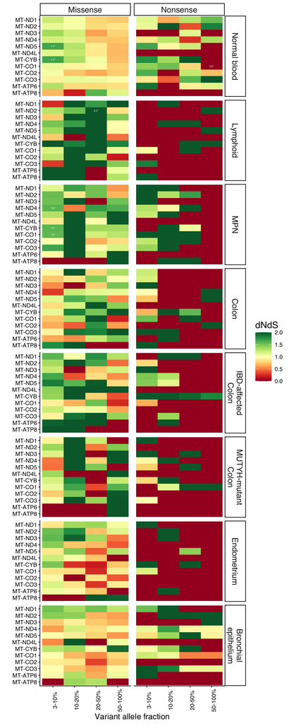

```r
gene_order=c(paste0("MT-ND",1:6),"MT-ND4L","MT-CYB",paste0("MT-CO",1:3),"MT-ATP6","MT-ATP8")
gene_order<-gene_order[gene_order%in%target_genes]

selcv_res_by_tissue_and_vaf<-Map(list1=dndscv_by_tissue_and_vaf,this_tissue=names(dndscv_by_tissue_and_vaf),function(list1,this_tissue) {

  Map(dndsout=list1,VAF_bin=new_VAF_groups[-1],function(dndsout,VAF_bin) {
    temp<-dndsout$sel_cv%>%
      dplyr::select(gene_name,wmis_cv,wnon_cv,qmis_cv,qtrunc_cv)

    dplyr::bind_rows(temp%>%dplyr::select(gene_name,"dNdS"=wmis_cv,"qval"=qmis_cv)%>%mutate(type="Missense"),
                     temp%>%dplyr::select(gene_name,"dNdS"=wnon_cv,"qval"=qtrunc_cv)%>%mutate(type="Nonsense"))%>%
      mutate(VAF_group=VAF_bin)
  })%>%dplyr::bind_rows()%>%
    mutate(VAF_group=factor(VAF_group,levels=VAF_groups$labels[-1]),tissue=this_tissue)

})%>%dplyr::bind_rows()

dnds_heatmap_by_tissue_and_vaf_by_gene<-selcv_res_by_tissue_and_vaf%>%
  mutate(dnds_if_signif=ifelse(qval<qval_cutoff,paste0(sprintf(dNdS, fmt = '%#.1f'),"*"),""),
         dNdS=ifelse(dNdS>2,2,dNdS),
         gene_name=factor(gene_name,levels=rev(gene_order)),
         tissue=factor(name_conversion_vec[tissue],levels=name_conversion_vec))%>%
  filter(VAF_group%in%VAF_groups$labels[-1] & tissue!="Blood")%>%
  ggplot(aes(y=gene_name,x=VAF_group,fill=dNdS,label=dnds_if_signif))+
  geom_tile()+
  facet_grid(tissue~type)+
  geom_text(col="white",size=1.5)+
  theme_classic()+
  my_markdown_theme+
  theme(axis.text.x=element_text(angle=90))+
  scale_fill_gradientn(colors=RColorBrewer::brewer.pal(n=11,name = "RdYlGn"))+
  labs(x="Variant allele fraction",y="")
dnds_heatmap_by_tissue_and_vaf_by_gene
```